# **NBA Most Improved Player/Most Valuable Player Predictor**

# **Data Science Final Portfolio**

*By* **Gabriel Epstein** *and* **Patrick Callahan**

**Project Websites**

[Final Portfolio GitHub Repository](https://github.com/GabrielEpstein/DataScienceFinalPortfolio)

[Final Portfolio Project Planning](https://github.com/users/GabrielEpstein/projects/6)

[Final Portfolio Website (Hosted by GitHub Pages)](https://gabrielepstein.github.io/DataScienceFinalPortfolio/)

## **Project Background, Logistics, Goals, and Data**

**Motivation:** This project is our Final Project Portfolio for the Intro To Data Science Course (CMPS-3160) at Tulane University.

**Project Idea / Plan:** Stats tell a story. The NBA MVP award (like the MIP award) is selected based on the subjective opinion of broadcasters, announcers, sports journalists, etc. These people each get to cast votes (1st place, 2nd place, and 3rd place votes are all worth a different amount of points, 1st being worth the most) for who they believe is the MVP. The player with the highest share of votes is the winner. The equation for this is as follows:

$\text{Share} = \frac{\text{MVP Voting Points}}{ \text{Total Possible MVP Points}}$

We want to discover if we can predict the Most Valuable or Improved Player through data analytics, or if there are chapters missing from that story.

The data below incorporates many advanced statistics, including play by play information for every player, season wide basic statistics, statistics per 100 possessions, and more. We believe we can use a combination of this data to create a model that can determine the upcoming NBA MVP.

**Project Goal:** Our goal is to develop a predictive model that accurately anticipates the next NBA MVP based on a variety of metrics including historical performance data and individual statistics, to uncover the most influential factors contributing to MVP recognition by conducting in-depth analyses of individual and team statistics and to test the model against historical MVP outcomes to assess its performance through cross-validation techniques.

**Collaboration Plan**

Our plan is to meet once a week, whether it's after class or on Zoom. We have a [GitHub Repository](https://github.com/GabrielEpstein/DataScienceFinalPortfolio) with a [project timeline](https://github.com/users/GabrielEpstein/projects/6) and a shared Google Colab Notebook to work on the project. We will meet to discuss our progress and the direction we are heading, and work on our assigned tasks individually, collaborating with eachother when necessary and keeping eachother informed on our current goal.

**Relevant Links:**

*NBA Stat FAQ to help identify statistics used and discrepencies in statistics tracked*

[FAQ | Stats | NBA.com](https://www.nba.com/stats/help/faq)

*The following data is used in Milestone 1*

We downloaded the following dataset and its accompanying .csv files to upload to Google Drive for access in our ETL:

[NBA Stats (1947-Present)](https://www.kaggle.com/datasets/sumitrodatta/nba-aba-baa-stats/data)

*The following data may be used in Milestone 2 and beyond*

[NBA Database](https://www.kaggle.com/datasets/wyattowalsh/basketball)

# **Extraction, Transformation, and Loading!**

**Mounting Google Drive**

Note: Below shows exactly what *we* did, and how *we* did it. The only difference is that we have included instructions for visitors from GitHub for running the project.

Our project begins with ETL.

Below, we are mounting Google Drive, importing libraries, and importing data to be used for Milestones 1 and 2.

```python
# Instructions to users to navigate to the folder where they have uploaded the zip file from our GitHub repository
from google.colab import drive
drive.mount('/content/drive')

print("Navigate to the directory in Google Drive where you have uploaded the project ZIP file using the command below.")
%cd /content/drive/'path to your directory here'
```

```python
# Mounting my google drive for access to the datasets
from google.colab import drive
drive.mount('/content/drive')
%cd /content/drive/MyDrive/Colab Notebooks/Intro to Data Science/Data Science Final Portfolio
```

```
/content/drive/MyDrive/Colab Notebooks/Intro to Data Science/Data Science Final Portfolio
```

**Importing Libraries:** Below, we are importing some of the libraries we will be using to analyze this data in Jupyter Notebooks. So far, I am using Pandas and NumPy libraries, and will be using MatLab's Plotting Library as well as Seaborn.

```python
# Importing different libraries for use in analysis
import pandas as pd
import numpy as np
import matplotlib
import matplotlib.pyplot as plt
import seaborn as sns
```

```python
# Formatting the output
pd.set_option('display.max_columns', None)  # Shows all columns
pd.set_option('display.max_rows', 100)  # Shows 100 rows
pd.set_option('display.width', None)  # Utilizes the maximum width of your terminal
```

**Importing Data:** Here, we are importing some data from the first dataset to use that we found from [Kaggle](https://kaggle.com), the "world's largest data science community with powerful tools and resources to help you achieve your data science goals." Then we use the .head() function to visually verify that the dataset seems to have been imported without problems!

*About the Data:* This data is from the 'Player Shooting' csv. It contains stats by player and season pretaining to individual players shooting statistics, including their field goal percentage, the average distance of their field goals, their field goal attempts and percentages by distance, and more.

```python
# Specifying the file paths used
ppg_file_path = 'Data Sets/NBA Stats (1947-Present)/Player Per Game.csv'
ps_file_path = 'Data Sets/NBA Stats (1947-Present)/Player Shooting.csv'

# Reading the CSVs into DataFrames
player_per_game_df = pd.read_csv(ppg_file_path)
player_shooting_df = pd.read_csv(ps_file_path)
```

```python
# Displaying the first 5 rows of each DataFrame
print('Player Per Game Stats:\n', player_per_game_df.head(),'\n\n' 'Player Shooting Stats:\n', player_shooting_df.head())
```

```
Player Per Game Stats:
    seas_id  season  player_id         player  birth_year pos   age  experience   lg   tm   g  \
0    31136    2024       5025     A.J. Green         NaN  SG  24.0           2  NBA  MIL  39
1    31137    2024       5026    A.J. Lawson         NaN  SG  23.0           2  NBA  DAL  28
2    31138    2024       5027     AJ Griffin         NaN  SF  20.0           2  NBA  ATL  18
3    31139    2024       4219   Aaron Gordon         NaN  PF  28.0          10  NBA  DEN  54
4    31140    2024       4582  Aaron Holiday         NaN  PG  27.0           6  NBA  HOU  56

     gs  mp_per_game  fg_per_game  fga_per_game  fg_percent  x3p_per_game  x3pa_per_game  \
0   0.0          9.2          1.4           3.3       0.438           1.2            2.8
1   0.0          8.3          1.4           3.0       0.471           0.5            1.4
2   0.0          7.3          0.7           2.5       0.289           0.5            1.8
3  54.0         31.5          5.5           9.8       0.557           0.5            1.8
4   1.0         17.3          2.5           5.5       0.455           1.2            3.0

```

[output cut: 77 more lines]

## Data Cleanup

### Cleaning player_shooting_df

Let's start with the player_shooting_df. We will identify the unique columns in the data, checking the dtypes, checking for NaNs, and filling in some missing data.

```python
#See unique column names
player_shooting_df.columns.unique()
```

```
Index(['seas_id', 'season', 'player_id', 'player', 'birth_year', 'pos', 'age', 'experience', 'lg',
       'tm', 'g', 'mp', 'fg_percent', 'avg_dist_fga', 'percent_fga_from_x2p_range',
       'percent_fga_from_x0_3_range', 'percent_fga_from_x3_10_range',
       'percent_fga_from_x10_16_range', 'percent_fga_from_x16_3p_range',
       'percent_fga_from_x3p_range', 'fg_percent_from_x2p_range', 'fg_percent_from_x0_3_range',
       'fg_percent_from_x3_10_range', 'fg_percent_from_x10_16_range',
       'fg_percent_from_x16_3p_range', 'fg_percent_from_x3p_range', 'percent_assisted_x2p_fg',
       'percent_assisted_x3p_fg', 'percent_dunks_of_fga', 'num_of_dunks',
       'percent_corner_3s_of_3pa', 'corner_3_point_percent', 'num_heaves_attempted',
       'num_heaves_made'],
      dtype='object')
```

```python
# Checking the dtypes of the different columns
player_shooting_df.dtypes
```

```
seas_id                            int64
season                             int64
player_id                          int64
player                            object
birth_year                       float64
pos                               object
age                                int64
experience                         int64
lg                                object
tm                                object
g                                  int64
mp                                 int64
fg_percent                       float64
avg_dist_fga                     float64
percent_fga_from_x2p_range       float64
percent_fga_from_x0_3_range      float64
percent_fga_from_x3_10_range     float64
percent_fga_from_x10_16_range    float64
percent_fga_from_x16_3p_range    float64
percent_fga_from_x3p_range       float64
fg_percent_from_x2p_range        float64
fg_percent_from_x0_3_range       float64
fg_percent_from_x3_10_range      float64
fg_percent_from_x10_16_range     float64
fg_percent_from_x16_3p_range     float64
fg_percent_from_x3p_range        float64
percent_assisted_x2p_fg          float64
percent_assisted_x3p_fg          float64
percent_dunks_of_fga             float64
num_of_dunks                       int64
percent_corner_3s_of_3pa         float64
corner_3_point_percent           float64
num_heaves_attempted               int64
num_heaves_made                    int64
dtype: object
```

```python
# Checking for NaNs
player_shooting_df.isnull().sum()
```

```
seas_id                              0
season                               0
player_id                            0
player                               0
birth_year                       16531
pos                                  0
age                                  0
experience                           0
lg                                   0
tm                                   0
g                                    0
mp                                   0
fg_percent                         109
avg_dist_fga                       109
percent_fga_from_x2p_range         109
percent_fga_from_x0_3_range        109
percent_fga_from_x3_10_range       109
percent_fga_from_x10_16_range      109
percent_fga_from_x16_3p_range      109
percent_fga_from_x3p_range         109
fg_percent_from_x2p_range          190
fg_percent_from_x0_3_range         578
fg_percent_from_x3_10_range        920
fg_percent_from_x10_16_range      1345
fg_percent_from_x16_3p_range      1481
fg_percent_from_x3p_range         2429
percent_assisted_x2p_fg            482
percent_assisted_x3p_fg           4590
percent_dunks_of_fga               109
num_of_dunks                         0
percent_corner_3s_of_3pa          2429
corner_3_point_percent            4522
num_heaves_attempted                 0
num_heaves_made                      0
dtype: int64
```

Since we are missing a lot of birth years but no ages, we will drop the 'birth_year' column using the Pandas .drop() function.

```python
# Using the .drop() function and specifying inplace = True to make the changes permanent within the dataframe.
player_shooting_df.drop(columns = 'birth_year', inplace = True)
player_shooting_df.head()
```

|  | seas_id | season | player_id | player | pos | age | experience | lg | tm | g | mp | fg_percent | avg_dist_fga | percent_fga_from_x2p_range | percent_fga_from_x0_3_range | percent_fga_from_x3_10_range | percent_fga_from_x10_16_range | percent_fga_from_x16_3p_range | percent_fga_from_x3p_range | fg_percent_from_x2p_range | fg_percent_from_x0_3_range | fg_percent_from_x3_10_range | fg_percent_from_x10_16_range | fg_percent_from_x16_3p_range | fg_percent_from_x3p_range | percent_assisted_x2p_fg | percent_assisted_x3p_fg | percent_dunks_of_fga | num_of_dunks | … |
| --- | --- | --- | --- | --- | --- | --- | --- | --- | --- | --- | --- | --- | --- | --- | --- | --- | --- | --- | --- | --- | --- | --- | --- | --- | --- | --- | --- | --- | --- | --- |
| 0 | 31136 | 2024 | 5025 | A.J. Green | SG | 24 | 2 | NBA | MIL | 39 | 357 | 0.438 | 24.0 | 0.133 | 0.023 | 0.023 | 0.023 | 0.063 | 0.867 | 0.529 | 1.000 | 0.333 | 0.333 | 0.500 | 0.423 | 1.000 | 0.915 | 0.000 | 0 | … |
| 1 | 31137 | 2024 | 5026 | A.J. Lawson | SG | 23 | 2 | NBA | DAL | 28 | 231 | 0.471 | 12.7 | 0.529 | 0.329 | 0.188 | 0.012 | 0.000 | 0.471 | 0.600 | 0.857 | 0.188 | 0.000 | NaN | 0.325 | 0.519 | 1.000 | 0.129 | 10 | … |
| 2 | 31138 | 2024 | 5027 | AJ Griffin | SF | 20 | 2 | NBA | ATL | 18 | 132 | 0.289 | 21.3 | 0.267 | 0.044 | 0.111 | 0.044 | 0.067 | 0.733 | 0.333 | 1.000 | 0.200 | 0.000 | 0.333 | 0.273 | 0.750 | 0.889 | 0.022 | 1 | … |
| 3 | 31139 | 2024 | 4219 | Aaron Gordon | PF | 28 | 10 | NBA | DEN | 54 | 1699 | 0.557 | 7.4 | 0.814 | 0.537 | 0.203 | 0.053 | 0.021 | 0.186 | 0.618 | 0.758 | 0.380 | 0.214 | 0.364 | 0.293 | 0.644 | 0.793 | 0.262 | 128 | … |
| 4 | 31140 | 2024 | 4582 | Aaron Holiday | PG | 27 | 6 | NBA | HOU | 56 | 967 | 0.455 | 17.4 | 0.465 | 0.132 | 0.168 | 0.119 | 0.045 | 0.535 | 0.507 | 0.634 | 0.462 | 0.514 | 0.286 | 0.410 | 0.274 | 0.838 | 0.006 | 2 | … |

(This is something we will have to address when doing statistical analysis later on, as we will have to decide whether to include players who have not take certain types of shot from that analysis so as to avoid skewing the data by filling NaNs with 0s.)

```python
# Here we will attempt to minimize the discrepancy of NaN and 0 percentages for two-point shot attempts

# Define the columns which indicate percentage of field goals attempted from two-point ranges and three-point range
attempt_columns = [
    'percent_fga_from_x2p_range',
    'percent_fga_from_x0_3_range',
    'percent_fga_from_x3_10_range',
    'percent_fga_from_x10_16_range',
    'percent_fga_from_x16_3p_range',
    'percent_fga_from_x3p_range'
]

# Define the corresponding shooting percentage columns
percent_columns = [
    'fg_percent_from_x2p_range',
    'fg_percent_from_x0_3_range',
    'fg_percent_from_x3_10_range',
    'fg_percent_from_x10_16_range',
    'fg_percent_from_x16_3p_range',
    'fg_percent_from_x3p_range'
]

# Create a copy of the dataframe for the relevant columns before replacement
before_replacement = player_shooting_df[attempt_columns + percent_columns].copy()

# Apply conditional logic to fill NaNs where attempt percentage >= 0
for attempt_col, percent_col in zip(attempt_columns, percent_columns):

    # Replace NaNs with 0 in the shooting percentage column where attempt percentage is >= 0
    player_shooting_df.loc[player_shooting_df[attempt_col] >= 0, percent_col] = player_shooting_df.loc[player_shooting_df[attempt_col] >= 0, percent_col].fillna(0)

# After replacements - check for differences
after_replacement = player_shooting_df[attempt_columns + percent_columns]

# Check the before_replacement DataFrame for NaN values
for attempt_col, percent_col in zip(attempt_columns, percent_columns):
    condition = (before_replacement[attempt_col] > 0) & (before_replacement[percent_col].isnull())
    if condition.any():
        print(f"Rows with non-negative attempts in {attempt_col} but NaN in {percent_col} before replacement:")
        print(before_replacement[condition][[attempt_col, percent_col]])
    else:
        print(f"No discrepancies in {attempt_col} and {percent_col} before replacement.")

# Check if there are rows with attempt percentage > 0 but corresponding shooting percentage is NaN after the operation
for attempt_col, percent_col in zip(attempt_columns, percent_columns):
    condition = (after_replacement[attempt_col] > 0) & (after_replacement[percent_col].isnull())
    if condition.any():
        print(f"Rows with non-negative attempts in {attempt_col} but NaN in {percent_col} after replacement:")
        print(after_replacement[condition][[attempt_col, percent_col]])
    else:
        print(f"No discrepancies found in {attempt_col} and {percent_col} after replacement.")
```

```
No discrepancies in percent_fga_from_x2p_range and fg_percent_from_x2p_range before replacement.
No discrepancies in percent_fga_from_x0_3_range and fg_percent_from_x0_3_range before replacement.
No discrepancies in percent_fga_from_x3_10_range and fg_percent_from_x3_10_range before replacement.
No discrepancies in percent_fga_from_x10_16_range and fg_percent_from_x10_16_range before replacement.
No discrepancies in percent_fga_from_x16_3p_range and fg_percent_from_x16_3p_range before replacement.
No discrepancies in percent_fga_from_x3p_range and fg_percent_from_x3p_range before replacement.
No discrepancies found in percent_fga_from_x2p_range and fg_percent_from_x2p_range after replacement.
No discrepancies found in percent_fga_from_x0_3_range and fg_percent_from_x0_3_range after replacement.
No discrepancies found in percent_fga_from_x3_10_range and fg_percent_from_x3_10_range after replacement.
No discrepancies found in percent_fga_from_x10_16_range and fg_percent_from_x10_16_range after replacement.
No discrepancies found in percent_fga_from_x16_3p_range and fg_percent_from_x16_3p_range after replacement.
No discrepancies found in percent_fga_from_x3p_range and fg_percent_from_x3p_range after replacement.
```

It appears we will have to work on cleaning up this data some more another time. This will likely involve manually sifting through the csv file to check what is happening with NaNs to see how we should appropriately handle them!

### Cleaning player_per_game_df

Now let's do some cleaning for our player_per_game_df. We will do the same process that we did for player_shooting_df.

```python
#See unique column names
player_per_game_df.columns.unique()
```

```
Index(['seas_id', 'season', 'player_id', 'player', 'birth_year', 'pos', 'age', 'experience', 'lg',
       'tm', 'g', 'gs', 'mp_per_game', 'fg_per_game', 'fga_per_game', 'fg_percent', 'x3p_per_game',
       'x3pa_per_game', 'x3p_percent', 'x2p_per_game', 'x2pa_per_game', 'x2p_percent',
       'e_fg_percent', 'ft_per_game', 'fta_per_game', 'ft_percent', 'orb_per_game', 'drb_per_game',
       'trb_per_game', 'ast_per_game', 'stl_per_game', 'blk_per_game', 'tov_per_game',
       'pf_per_game', 'pts_per_game'],
      dtype='object')
```

```python
# Checking the dtypes of the different columns
player_per_game_df.dtypes
```

```
seas_id            int64
season             int64
player_id          int64
player            object
birth_year       float64
pos               object
age              float64
experience         int64
lg                object
tm                object
g                  int64
gs               float64
mp_per_game      float64
fg_per_game      float64
fga_per_game     float64
fg_percent       float64
x3p_per_game     float64
x3pa_per_game    float64
x3p_percent      float64
x2p_per_game     float64
x2pa_per_game    float64
x2p_percent      float64
e_fg_percent     float64
ft_per_game      float64
fta_per_game     float64
ft_percent       float64
orb_per_game     float64
drb_per_game     float64
trb_per_game     float64
ast_per_game     float64
stl_per_game     float64
blk_per_game     float64
tov_per_game     float64
pf_per_game      float64
pts_per_game     float64
dtype: object
```

```python
# Checking for NaNs
player_per_game_df.isnull().sum()
```

```
seas_id              0
season               0
player_id            0
player               0
birth_year       28944
pos                  0
age                 22
experience           0
lg                   0
tm                   0
g                    0
gs                8637
mp_per_game       1083
fg_per_game          0
fga_per_game         0
fg_percent         163
x3p_per_game      6352
x3pa_per_game     6352
x3p_percent      10545
x2p_per_game         0
x2pa_per_game        0
x2p_percent        250
e_fg_percent       163
ft_per_game          0
fta_per_game         0
ft_percent        1303
orb_per_game      4657
drb_per_game      4657
trb_per_game       894
ast_per_game         0
stl_per_game      5626
blk_per_game      5625
tov_per_game      5635
pf_per_game          0
pts_per_game         0
dtype: int64
```

```python
# Using the .drop() function and specifying inplace = True to make the changes permanent within the dataframe.
player_per_game_df.drop(columns = 'birth_year', inplace = True)
player_per_game_df.head()
```

|  | seas_id | season | player_id | player | pos | age | experience | lg | tm | g | gs | mp_per_game | fg_per_game | fga_per_game | fg_percent | x3p_per_game | x3pa_per_game | x3p_percent | x2p_per_game | x2pa_per_game | x2p_percent | e_fg_percent | ft_per_game | fta_per_game | ft_percent | orb_per_game | drb_per_game | trb_per_game | ast_per_game | … |
| --- | --- | --- | --- | --- | --- | --- | --- | --- | --- | --- | --- | --- | --- | --- | --- | --- | --- | --- | --- | --- | --- | --- | --- | --- | --- | --- | --- | --- | --- | --- |
| 0 | 31136 | 2024 | 5025 | A.J. Green | SG | 24.0 | 2 | NBA | MIL | 39 | 0.0 | 9.2 | 1.4 | 3.3 | 0.438 | 1.2 | 2.8 | 0.423 | 0.2 | 0.4 | 0.529 | 0.621 | 0.2 | 0.2 | 1.000 | 0.2 | 0.9 | 1.0 | 0.5 | … |
| 1 | 31137 | 2024 | 5026 | A.J. Lawson | SG | 23.0 | 2 | NBA | DAL | 28 | 0.0 | 8.3 | 1.4 | 3.0 | 0.471 | 0.5 | 1.4 | 0.325 | 1.0 | 1.6 | 0.600 | 0.547 | 0.4 | 0.7 | 0.632 | 0.4 | 0.8 | 1.2 | 0.5 | … |
| 2 | 31138 | 2024 | 5027 | AJ Griffin | SF | 20.0 | 2 | NBA | ATL | 18 | 0.0 | 7.3 | 0.7 | 2.5 | 0.289 | 0.5 | 1.8 | 0.273 | 0.2 | 0.7 | 0.333 | 0.389 | 0.1 | 0.1 | 1.000 | 0.1 | 0.7 | 0.8 | 0.2 | … |
| 3 | 31139 | 2024 | 4219 | Aaron Gordon | PF | 28.0 | 10 | NBA | DEN | 54 | 54.0 | 31.5 | 5.5 | 9.8 | 0.557 | 0.5 | 1.8 | 0.293 | 4.9 | 8.0 | 0.618 | 0.585 | 2.4 | 3.7 | 0.652 | 2.4 | 4.1 | 6.5 | 3.2 | … |
| 4 | 31140 | 2024 | 4582 | Aaron Holiday | PG | 27.0 | 6 | NBA | HOU | 56 | 1.0 | 17.3 | 2.5 | 5.5 | 0.455 | 1.2 | 3.0 | 0.410 | 1.3 | 2.6 | 0.507 | 0.565 | 0.7 | 0.8 | 0.889 | 0.3 | 1.4 | 1.7 | 1.8 | … |

Let's see where the NaN values for age are.

```python
# Filtering the dataframe for rows where the 'age' column is NaN
ppg_nan_age_df = player_per_game_df[player_per_game_df['age'].isnull()]
ppg_nan_age_df.head(30)
```

|  | seas_id | season | player_id | player | pos | age | experience | lg | tm | g | gs | mp_per_game | fg_per_game | fga_per_game | fg_percent | x3p_per_game | x3pa_per_game | x3p_percent | x2p_per_game | x2pa_per_game | x2p_percent | e_fg_percent | ft_per_game | fta_per_game | ft_percent | orb_per_game | drb_per_game | trb_per_game | ast_per_game | … |
| --- | --- | --- | --- | --- | --- | --- | --- | --- | --- | --- | --- | --- | --- | --- | --- | --- | --- | --- | --- | --- | --- | --- | --- | --- | --- | --- | --- | --- | --- | --- |
| 26500 | 5554 | 1973 | 1470 | Pete Smith | PF | NaN | 1 | ABA | SDA | 5 | NaN | 6.4 | 0.4 | 2.4 | 0.167 | 0.0 | 0.4 | 0.0 | 0.4 | 2.0 | 0.200 | 0.167 | 0.0 | 0.0 | NaN | 0.6 | 1.0 | 1.6 | 0.2 | … |
| 27132 | 4391 | 1971 | 1253 | Clarence Brookins | F | NaN | 1 | ABA | FLO | 8 | NaN | 7.4 | 1.0 | 3.3 | 0.308 | 0.0 | 0.1 | 0.0 | 1.0 | 3.1 | 0.320 | 0.308 | 0.6 | 1.5 | 0.417 | 1.0 | 0.5 | 1.5 | 0.1 | … |
| 27286 | 4545 | 1971 | 1291 | Jim Wilson | G | NaN | 1 | ABA | PTC | 6 | NaN | 7.3 | 0.2 | 1.3 | 0.125 | 0.0 | 0.0 | NaN | 0.2 | 1.3 | 0.125 | 0.125 | 0.7 | 1.0 | 0.667 | 0.2 | 0.8 | 1.0 | 1.3 | … |
| 27888 | 4293 | 1970 | 1231 | Walter Byrd | PF | NaN | 1 | ABA | MMF | 22 | NaN | 5.0 | 0.6 | 2.0 | 0.326 | 0.0 | 0.0 | 0.0 | 0.6 | 1.9 | 0.333 | 0.326 | 0.2 | 0.8 | 0.294 | 0.4 | 0.8 | 1.1 | 0.3 | … |
| 27899 | 4304 | 1970 | 1233 | Wilbur Kirkland | F | NaN | 1 | ABA | PTP | 2 | NaN | 13.5 | 1.5 | 3.5 | 0.429 | 0.0 | 0.0 | NaN | 1.5 | 3.5 | 0.429 | 0.429 | 0.0 | 0.0 | NaN | 0.5 | 5.0 | 5.5 | 0.5 | … |
| 27972 | 3550 | 1969 | 1081 | Charles Parks | F | NaN | 1 | ABA | DNR | 2 | NaN | 2.5 | 0.0 | 0.5 | 0.000 | 0.0 | 0.0 | NaN | 0.0 | 0.5 | 0.000 | 0.000 | 0.0 | 0.0 | NaN | 0.0 | 0.0 | 0.0 | 0.0 | … |
| 28349 | 3141 | 1968 | 904 | Bill Allen | C | NaN | 1 | ABA | ANA | 38 | NaN | 22.6 | 3.2 | 7.4 | 0.429 | 0.1 | 0.1 | 1.0 | 3.1 | 7.3 | 0.424 | 0.432 | 1.5 | 2.6 | 0.586 | NaN | NaN | 7.1 | 0.6 | … |
| 28378 | 3170 | 1968 | 922 | Bobby Wilson | PF | NaN | 1 | ABA | DLC | 69 | NaN | 22.6 | 3.3 | 8.4 | 0.389 | 0.0 | 0.0 | 0.5 | 3.3 | 8.4 | 0.389 | 0.390 | 2.4 | 3.8 | 0.615 | NaN | NaN | 6.5 | 0.8 | … |
| 28404 | 3196 | 1968 | 939 | Darrell Hardy | F | NaN | 1 | ABA | HSM | 17 | NaN | 10.1 | 1.9 | 4.4 | 0.432 | 0.0 | 0.1 | 0.0 | 1.9 | 4.3 | 0.438 | 0.432 | 1.5 | 2.1 | 0.714 | NaN | NaN | 3.3 | 0.5 | … |
| 28414 | 3206 | 1968 | 945 | Dexter Westbrook | F | NaN | 1 | ABA | TOT | 12 | NaN | 10.6 | 1.6 | 3.3 | 0.487 | 0.0 | 0.0 | NaN | 1.6 | 3.3 | 0.487 | 0.487 | 0.8 | 1.2 | 0.714 | NaN | NaN | 1.9 | 0.4 | … |
| 28415 | 3207 | 1968 | 945 | Dexter Westbrook | F | NaN | 1 | ABA | NJA | 7 | NaN | 8.4 | 1.7 | 2.7 | 0.632 | 0.0 | 0.0 | NaN | 1.7 | 2.7 | 0.632 | 0.632 | 1.0 | 1.3 | 0.778 | NaN | NaN | 1.3 | 0.3 | … |
| 28416 | 3208 | 1968 | 945 | Dexter Westbrook | F | NaN | 1 | ABA | PTP | 5 | NaN | 13.6 | 1.4 | 4.0 | 0.350 | 0.0 | 0.0 | NaN | 1.4 | 4.0 | 0.350 | 0.350 | 0.6 | 1.0 | 0.600 | NaN | NaN | 2.8 | 0.6 | … |
| 28418 | 3210 | 1968 | 946 | Dick Lee | F | NaN | 1 | ABA | ANA | 2 | NaN | 1.0 | 0.0 | 0.0 | NaN | 0.0 | 0.0 | NaN | 0.0 | 0.0 | NaN | NaN | 0.0 | 0.0 | NaN | NaN | NaN | 0.5 | 0.5 | … |
| 28435 | 3227 | 1968 | 952 | Errol Palmer | SF | NaN | 1 | ABA | MNM | 63 | NaN | 18.9 | 2.6 | 7.2 | 0.364 | 0.0 | 0.0 | NaN | 2.6 | 7.2 | 0.364 | 0.364 | 2.7 | 4.0 | 0.672 | NaN | NaN | 7.5 | 1.4 | … |
| 28452 | 3244 | 1968 | 956 | Gary Turner | F | NaN | 1 | ABA | HSM | 2 | NaN | 10.5 | 1.0 | 1.0 | 1.000 | 0.0 | 0.0 | NaN | 1.0 | 1.0 | 1.000 | 1.000 | 1.0 | 1.5 | 0.667 | NaN | NaN | 1.5 | 0.0 | … |
| 28607 | 3399 | 1968 | 1023 | R.B. Lynam | G | NaN | 1 | ABA | DNR | 7 | NaN | 5.6 | 0.7 | 2.4 | 0.294 | 0.0 | 0.1 | 0.0 | 0.7 | 2.3 | 0.313 | 0.294 | 1.0 | 1.1 | 0.875 | NaN | NaN | 0.7 | 0.0 | … |
| 28609 | 3401 | 1968 | 1025 | Randy Stoll | PF | NaN | 1 | ABA | ANA | 25 | NaN | 16.1 | 2.6 | 5.5 | 0.478 | 0.0 | 0.0 | NaN | 2.6 | 5.5 | 0.478 | 0.478 | 0.4 | 1.0 | 0.400 | NaN | NaN | 3.6 | 0.5 | … |
| 28618 | 3410 | 1968 | 1031 | Richie Moore | SG | NaN | 1 | ABA | DNR | 18 | NaN | 11.7 | 1.3 | 3.9 | 0.338 | 0.0 | 0.1 | 0.0 | 1.3 | 3.8 | 0.348 | 0.338 | 1.2 | 1.6 | 0.750 | NaN | NaN | 1.1 | 0.4 | … |
| 28690 | 3482 | 1968 | 1067 | Willis Thomas | SG | NaN | 1 | ABA | TOT | 62 | NaN | 17.2 | 3.9 | 8.9 | 0.442 | 0.0 | 0.0 | 0.0 | 3.9 | 8.8 | 0.444 | 0.442 | 1.1 | 1.5 | 0.742 | NaN | NaN | 1.8 | 0.9 | … |
| 28691 | 3483 | 1968 | 1067 | Willis Thomas | SG | NaN | 1 | ABA | DNR | 24 | NaN | 22.6 | 5.7 | 12.7 | 0.446 | 0.0 | 0.1 | 0.0 | 5.7 | 12.6 | 0.449 | 0.446 | 0.9 | 1.3 | 0.688 | NaN | NaN | 2.4 | 1.0 | … |
| 28692 | 3484 | 1968 | 1067 | Willis Thomas | SG | NaN | 1 | ABA | ANA | 38 | NaN | 13.8 | 2.8 | 6.4 | 0.437 | 0.0 | 0.0 | 0.0 | 2.8 | 6.4 | 0.439 | 0.437 | 1.2 | 1.6 | 0.770 | NaN | NaN | 1.5 | 0.8 | … |
| 31716 | 107 | 1947 | 89 | Howie McCarty | F-G | NaN | 1 | BAA | DTF | 19 | NaN | NaN | 0.5 | 4.3 | 0.122 | NaN | NaN | NaN | 0.5 | 4.3 | 0.122 | 0.122 | 0.1 | 0.5 | 0.100 | NaN | NaN | NaN | 0.1 | … |

```python
# Filter the dataframe to keep only rows where 'lg' is 'NBA', overwriting the original DataFrame
player_per_game_df = player_per_game_df[player_per_game_df['lg'] == 'NBA']

# Now player_per_game_df contains only entries from the NBA
(player_per_game_df['lg']!='NBA').sum()
```

```
0
```

Great! Now let's do the same thing for the player_shooting_df, since we didn't think of doing it before, then we'll get back to cleaning our player_per_game_df.

```python
# Filter the dataframe to keep only rows where 'lg' is 'NBA', overwriting the original DataFrame
player_shooting_df = player_shooting_df[player_shooting_df['lg'] == 'NBA']

# Now player_per_game_df contains only entries from the NBA
(player_shooting_df['lg']!='NBA').sum()
```

```
0
```

Let's check the NaNs of our updated dataframes.

```python
player_per_game_df.isnull().sum()
```

```
seas_id             0
season              0
player_id           0
player              0
pos                 0
age                 0
experience          0
lg                  0
tm                  0
g                   0
gs               6417
mp_per_game       501
fg_per_game         0
fga_per_game        0
fg_percent        146
x3p_per_game     5770
x3pa_per_game    5770
x3p_percent      9621
x2p_per_game        0
x2pa_per_game       0
x2p_percent       233
e_fg_percent      146
ft_per_game         0
fta_per_game        0
ft_percent       1228
orb_per_game     3900
drb_per_game     3900
trb_per_game      312
ast_per_game        0
stl_per_game     3900
blk_per_game     3900
tov_per_game     5052
pf_per_game         0
pts_per_game        0
dtype: int64
```

No missing games (g), but 6,417 missing games started (gs). Is this a result of these players not playing in games (in which case, filling gs with 0 would be more appropriate) or is there missing data? Let's investigate.

```python
# Filter the dataframe for rows where 'gs' is NaN but 'g' is greater than 0
missing_gs_played_games = player_per_game_df[(player_per_game_df['gs'].isnull()) & (player_per_game_df['g'] > 0)]

# Display the first few rows of this filtered dataframe to investigate
print(missing_gs_played_games[['player', 'g', 'gs']].head(20))
```

```
                player   g  gs
23104    Abdul Jeelani  66 NaN
23105   Adrian Dantley  80 NaN
23106       Alan Hardy  22 NaN
23107     Alex English  81 NaN
23108    Allan Bristow  82 NaN
23109    Allen Leavell  79 NaN
23110      Alvan Adams  75 NaN
23111      Alvin Scott  82 NaN
23112   Andre McCarter  43 NaN
23114  Anthony Roberts  26 NaN
23115      Armond Hill  75 NaN
23116      Armond Hill  24 NaN
23117      Armond Hill  51 NaN
23118      Art Collins  29 NaN
23119    Artis Gilmore  82 NaN
23120      Austin Carr  47 NaN
23121      Austin Carr   8 NaN
23122      Austin Carr  39 NaN
23123     Ben Poquette  82 NaN
23124     Bernard King  81 NaN
```

```python
missing_gs_played_games.loc[23104]
```

```
seas_id                   8348
season                    1981
player_id                 1845
player           Abdul Jeelani
pos                         SF
age                       26.0
experience                   2
lg                         NBA
tm                         DAL
g                           66
gs                         NaN
mp_per_game               16.8
fg_per_game                2.8
fga_per_game               6.7
fg_percent               0.425
x3p_per_game               0.0
x3pa_per_game              0.0
x3p_percent                0.0
x2p_per_game               2.8
x2pa_per_game              6.7
x2p_percent              0.426
e_fg_percent             0.425
ft_per_game                2.7
fta_per_game               3.3
ft_percent               0.814
orb_per_game               1.3
drb_per_game               2.2
trb_per_game               3.5
ast_per_game               1.0
stl_per_game               0.7
blk_per_game               0.5
tov_per_game               1.3
pf_per_game                1.9
pts_per_game               8.4
Name: 23104, dtype: object
```

According to [FAQ | Stats | NBA.com](https://www.nba.com/stats/help/faq), certain stats were not tracked until later on in the league's history. There also seem to be some missing values, even after these stats were tracked. For example, Abdul Jeelani does not have any data pertaining to games started in 1981, even though the league began tracking games started in 1971. We will have to decide how to address this later on when doing deeper analytics.

Next, we will move onto EDA.

# **Exploratory Data Analysis**

## This will be the last section we work on for Milestone 1!

In this section, we will do some light EDA on our data showing 3 - 5 interesting summary statistics, a graphic showing an interesting property or distribution in the data and explaining their relevance to our question / investigation.

## Summary Statistics

Let's look at some basic summary statistics.

```python
# Let's look at the average percentage of field goal attempts from 3-point range
player_shooting_df['percent_fga_from_x3p_range'].mean()
```

```
0.26173929001203367
```

This is an interesting statistic (the average percentage of field goal attempts from 3-point range) in terms of league wide MVPs. For context, there have been 14 back-to-back league MVPs (by 12 players), and 3 back-to-back-to-back MVPs (MVP 3 years in a row) in league history. Looking at recent years, there have been 3 back-to-back MVPs, including Stephen Curry who won back-to-back MVPs in the 2014-2015 and 2015-2016 seasons. Stephen Curry is notorious for changing the league with his 'lights-out' 3-point shooting, landing him the first (and only) unanimous MVP in league history. Could this be indicative of 3-point shooting being a key factor in league MVP?

```python
# Let's see Steph Curry's shooting from the 2015-2016 season (his unanimous MVP season).
player_shooting_df[(player_shooting_df['player'] == 'Stephen Curry') & (player_shooting_df['season'] == 2016)][['percent_fga_from_x3p_range', 'fg_percent_from_x3p_range']]
```

|  | percent_fga_from_x3p_range | fg_percent_from_x3p_range |
| --- | --- | --- |
| 6006 | 0.554 | 0.454 |

As you can see, the first and only unanimous NBA MVP took 55.4% of all of his shots that season from the 3-point range, and was shooting 45.4% from 3-point range. How does this compare to the other two recent back-to-back league MVPs? Those two players would be Giannis Antentekounmpo and Nikola Jokic. Giannis Antetokounmpo won back-to-back MVP awards in the 2018-2019 and 2019-2020 Seasons. Nikola Jokić won back-to-back MVP awards in 2020-2021 and 2021-2022.

```python
# Let's filter for each player and their MVP seasons
curry_stats = player_shooting_df[
    (player_shooting_df['player'] == 'Stephen Curry') &
    ((player_shooting_df['season'] == 2015) | (player_shooting_df['season'] == 2016))][['player', 'season', 'percent_fga_from_x3p_range', 'fg_percent_from_x3p_range']]

giannis_stats = player_shooting_df[
    (player_shooting_df['player'] == 'Giannis Antetokounmpo') &
    ((player_shooting_df['season'] == 2019) | (player_shooting_df['season'] == 2020))][['player', 'season', 'percent_fga_from_x3p_range', 'fg_percent_from_x3p_range']]

jokic_stats = player_shooting_df[
    (player_shooting_df['player'] == 'Nikola Jokić') &
    ((player_shooting_df['season'] == 2021) | (player_shooting_df['season'] == 2022))][['player', 'season', 'percent_fga_from_x3p_range', 'fg_percent_from_x3p_range']]

# Concatenating the dataframes for easy viewing
mvp_comparison = pd.concat([curry_stats, giannis_stats, jokic_stats])

# Resetting the index for better readability
mvp_comparison.reset_index(drop=True, inplace=True)

mvp_comparison
```

|  | player | season | percent_fga_from_x3p_range | fg_percent_from_x3p_range |
| --- | --- | --- | --- | --- |
| 0 | Stephen Curry | 2016 | 0.554 | 0.454 |
| 1 | Stephen Curry | 2015 | 0.482 | 0.443 |
| 2 | Giannis Antetokounmpo | 2020 | 0.237 | 0.304 |
| 3 | Giannis Antetokounmpo | 2019 | 0.163 | 0.256 |
| 4 | Nikola Jokić | 2022 | 0.220 | 0.337 |
| 5 | Nikola Jokić | 2021 | 0.183 | 0.388 |

Interesting, the two more recent back-to-back (though not unanimous) MVPs were not particularly frequent 3-point shooters!

Let's look at another summary statistic, this time from player_per_game_df.

```python
# Looking at effective field goal percent, defined by the NBA as follows: "eFG% measures field goal percentage adjusting for the fact that a 3-point field goal is worth one more point than a 2-point field goal. The formula is eFG% = ((FGM + (0.5 * 3PM)) / FGA"
player_per_game_df['e_fg_percent'].mean()
```

```
0.45996369872317305
```

```python
# Filter for Stephen Curry's back-to-back MVP seasons (2014-2015, 2015-2016)
curry_efg = player_per_game_df[
    (player_per_game_df['player'] == 'Stephen Curry') &
    ((player_per_game_df['season'] == 2015) | (player_per_game_df['season'] == 2016))
][['player', 'season', 'e_fg_percent']]

# Filter for Giannis Antetokounmpo's back-to-back MVP seasons (2018-2019, 2019-2020)
giannis_efg = player_per_game_df[
    (player_per_game_df['player'] == 'Giannis Antetokounmpo') &
    ((player_per_game_df['season'] == 2019) | (player_per_game_df['season'] == 2020))
][['player', 'season', 'e_fg_percent']]

# Filter for Nikola Jokić's back-to-back MVP seasons (2020-2021, 2021-2022)
jokic_efg = player_per_game_df[
    (player_per_game_df['player'] == 'Nikola Jokić') &
    ((player_per_game_df['season'] == 2021) | (player_per_game_df['season'] == 2022))
][['player', 'season', 'e_fg_percent']]

# Concatenate the filtered DataFrames
mvp_efg_comparison = pd.concat([curry_efg, giannis_efg, jokic_efg])

# Reset the index for better readability
mvp_efg_comparison.reset_index(drop=True, inplace=True)

mvp_efg_comparison
```

|  | player | season | e_fg_percent |
| --- | --- | --- | --- |
| 0 | Stephen Curry | 2016 | 0.630 |
| 1 | Stephen Curry | 2015 | 0.594 |
| 2 | Giannis Antetokounmpo | 2020 | 0.589 |
| 3 | Giannis Antetokounmpo | 2019 | 0.599 |
| 4 | Nikola Jokić | 2022 | 0.620 |
| 5 | Nikola Jokić | 2021 | 0.602 |

Hmm, it seems that the 3 back-to-back MVPs have much more similar Effective Field Goal Percentages than 3-point statistics. They are all notably higher than the average across the dataset (roughtly 30% higher than the mean), and they are all within 4% of eachother!

Finally, let's look at a third statistic: field goal attempts per game.

```python
# Filter for Stephen Curry's back-to-back MVP seasons (2014-2015, 2015-2016)
curry_fga = player_per_game_df[
    (player_per_game_df['player'] == 'Stephen Curry') &
    ((player_per_game_df['season'] == 2015) | (player_per_game_df['season'] == 2016))
][['player', 'season', 'fga_per_game']]

# Filter for Giannis Antetokounmpo's back-to-back MVP seasons (2018-2019, 2019-2020)
giannis_fga = player_per_game_df[
    (player_per_game_df['player'] == 'Giannis Antetokounmpo') &
    ((player_per_game_df['season'] == 2019) | (player_per_game_df['season'] == 2020))
][['player', 'season', 'fga_per_game']]

# Filter for Nikola Jokić's back-to-back MVP seasons (2020-2021, 2021-2022)
jokic_fga = player_per_game_df[
    (player_per_game_df['player'] == 'Nikola Jokić') &
    ((player_per_game_df['season'] == 2021) | (player_per_game_df['season'] == 2022))
][['player', 'season', 'fga_per_game']]

# Concatenate the filtered DataFrames
mvp_fga_comparison = pd.concat([curry_fga, giannis_fga, jokic_fga])

# Reset the index for better readability
mvp_fga_comparison.reset_index(drop=True, inplace=True)

mvp_fga_comparison
```

|  | player | season | fga_per_game |
| --- | --- | --- | --- |
| 0 | Stephen Curry | 2016 | 20.2 |
| 1 | Stephen Curry | 2015 | 16.8 |
| 2 | Giannis Antetokounmpo | 2020 | 19.7 |
| 3 | Giannis Antetokounmpo | 2019 | 17.3 |
| 4 | Nikola Jokić | 2022 | 17.7 |
| 5 | Nikola Jokić | 2021 | 18.0 |

Can we now compare field goal attempts per game with effective field goal percent per game? Let's see below.

## Visualizations

Let's look at some of the data graphically

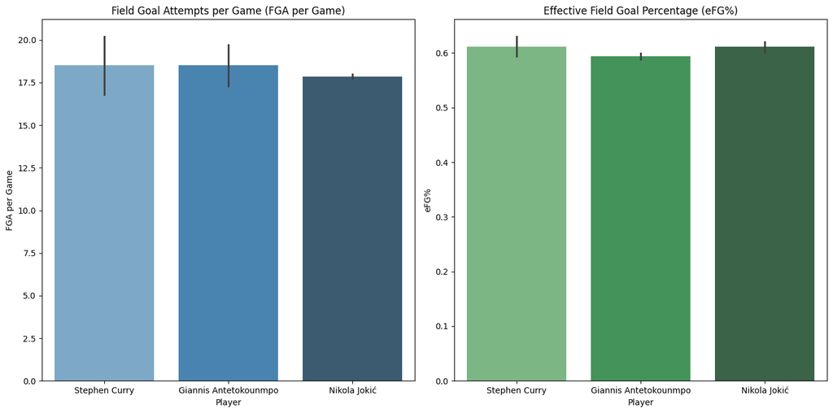

```python
# Combine the two DataFrames on 'player' and 'season'
mvp_stats_comparison = pd.merge(mvp_efg_comparison, mvp_fga_comparison, on=['player', 'season'])

# Set up the matplotlib figure
plt.figure(figsize=(14, 7))

# Plot 1: FGA per game
plt.subplot(1, 2, 1)  # 1 row, 2 columns, first plot
sns.barplot(data=mvp_stats_comparison, x='player', y='fga_per_game', hue='player', palette='Blues_d', legend=False)
plt.title('Field Goal Attempts per Game (FGA per Game)')
plt.xlabel('Player')
plt.ylabel('FGA per Game')

# Plot 2: eFG%
plt.subplot(1, 2, 2)  # 1 row, 2 columns, second plot
sns.barplot(data=mvp_stats_comparison, x='player', y='e_fg_percent', hue='player', palette='Greens_d', legend=False)
plt.title('Effective Field Goal Percentage (eFG%)')
plt.xlabel('Player')
plt.ylabel('eFG%')

# Adjust layout to prevent overlap
plt.tight_layout()

# Display the plots
plt.show()
```

# Further ETL and EDA (Milestone 2 Starts Here)

**DISCLAIMER**: There were some mild importing issues that arose from specific filepaths being used for importing the project files. This would cause issues for people attempting to run this project outside of my personal Google Drive, so pretty much everyone but me - those have been addressed!

## Clean Up, Continued

Before we continue our EDA, let's continue with out Data Cleanup efforts from our ETL phase. Let's look into the missing values some more.

Something we thought of would be if those players with missing values for fg percentages have 0 games played those seasons because of injuries or something. Let's check this.

```python
# Filter for rows where the fg_percent_from_x2p_range is NaN
missing_fg_percent_from_x2p = player_shooting_df[player_shooting_df['fg_percent_from_x2p_range'].isnull()]

# Now, display a sample of the rows with missing fg_percent_from_x2p values
print(missing_fg_percent_from_x2p.head())
```

```
     seas_id  season  player_id           player pos  age  experience   lg   tm  g  mp  \
44     31180    2024       3984  Bismack Biyombo   C   31          13  NBA  OKC  2   9
201    31337    2024       5140   Filip Petrušev   C   23           1  NBA  PHI  1   3
292    31428    2024       5060    Jason Preston  PG   24           2  NBA  UTA  1   1
294    31430    2024       4955    Javonte Smart  PG   24           2  NBA  PHI  1   1
354    31490    2024       4528   Justin Jackson  SF   28           7  NBA  MIN  2   1

     fg_percent  avg_dist_fga  percent_fga_from_x2p_range  percent_fga_from_x0_3_range  \
44          NaN           NaN                         NaN                          NaN
201         NaN           NaN                         NaN                          NaN
292         NaN           NaN                         NaN                          NaN
294         NaN           NaN                         NaN                          NaN
354         NaN           NaN                         NaN                          NaN

     percent_fga_from_x3_10_range  percent_fga_from_x10_16_range  percent_fga_from_x16_3p_range  \
```

[output cut: 40 more lines]

```python
# Filter for rows with NaN in the fg_percent_from_x2p_range column and check games played
missing_data_with_g = player_shooting_df[player_shooting_df['fg_percent_from_x2p_range'].isnull()][['player', 'season', 'tm', 'g', 'percent_fga_from_x2p_range', 'fg_percent_from_x2p_range']]

# Display the players who have zero games played
no_games_played = missing_data_with_g[missing_data_with_g['g'] == 0]
print(no_games_played)
```

```
Empty DataFrame
Columns: [player, season, tm, g, percent_fga_from_x2p_range, fg_percent_from_x2p_range]
Index: []
```

At this point, we've realized something crucial; there are no players with 0 games in this CSV. However, there are players with few enough games played or minutes played that they may not have attempted any shots, or may have taken fewer shots than required for the stats we have been looking to be tracked. To address this, we will look at player totals. Then we can compare between the different CSV files to see if certain NaNs can be explained!

### Importing Player Totals

Let's take a look at the 'Player Totals.csv' file to get a better overview of what's happening.

```python
# In the same format as before, let's import the 'Player Totals' CSV
pt_file_path = 'Data Sets/NBA Stats (1947-Present)/Player Totals.csv'
player_totals_df = pd.read_csv(pt_file_path)
```

```python
# Checking for NaNs
player_totals_df.isnull().sum()
```

```
seas_id             0
season              0
player_id           0
player              0
birth_year      28944
pos                 0
age                22
experience          0
lg                  0
tm                  0
g                   0
gs               8637
mp               1083
fg                  0
fga                 0
fg_percent        163
x3p              6352
x3pa             6352
x3p_percent     10545
x2p                 0
x2pa                0
x2p_percent       250
e_fg_percent      163
ft                  0
fta                 0
ft_percent       1303
orb              4657
drb              4657
trb               894
ast                 0
stl              5626
blk              5625
tov              5635
pf                  0
pts                 0
dtype: int64
```

Let's apply some of the changes we made to the two previous DataFrames to this one

```python
# Using the .drop() function and specifying inplace = True to make the changes permanent within the dataframe.
player_totals_df.drop(columns = ['birth_year'], inplace = True)

# Filter the dataframe to keep only rows where 'lg' is 'NBA', overwriting the original DataFrame
player_totals_df = player_totals_df[player_totals_df['lg'] == 'NBA']

# Now player_totals_df contains only entries from the NBA
(player_per_game_df['lg']!='NBA').sum()
```

```
0
```

```python
player_totals_df.head()
```

|  | seas_id | season | player_id | player | pos | age | experience | lg | tm | g | gs | mp | fg | fga | fg_percent | x3p | x3pa | x3p_percent | x2p | x2pa | x2p_percent | e_fg_percent | ft | fta | ft_percent | orb | drb | trb | ast | … |
| --- | --- | --- | --- | --- | --- | --- | --- | --- | --- | --- | --- | --- | --- | --- | --- | --- | --- | --- | --- | --- | --- | --- | --- | --- | --- | --- | --- | --- | --- | --- |
| 0 | 31136 | 2024 | 5025 | A.J. Green | SG | 24.0 | 2 | NBA | MIL | 39 | 0.0 | 357.0 | 56 | 128 | 0.438 | 47.0 | 111.0 | 0.423 | 9 | 17 | 0.529 | 0.621 | 8 | 8 | 1.000 | 6.0 | 34.0 | 40.0 | 21 | … |
| 1 | 31137 | 2024 | 5026 | A.J. Lawson | SG | 23.0 | 2 | NBA | DAL | 28 | 0.0 | 231.0 | 40 | 85 | 0.471 | 13.0 | 40.0 | 0.325 | 27 | 45 | 0.600 | 0.547 | 12 | 19 | 0.632 | 12.0 | 21.0 | 33.0 | 13 | … |
| 2 | 31138 | 2024 | 5027 | AJ Griffin | SF | 20.0 | 2 | NBA | ATL | 18 | 0.0 | 132.0 | 13 | 45 | 0.289 | 9.0 | 33.0 | 0.273 | 4 | 12 | 0.333 | 0.389 | 2 | 2 | 1.000 | 2.0 | 12.0 | 14.0 | 4 | … |
| 3 | 31139 | 2024 | 4219 | Aaron Gordon | PF | 28.0 | 10 | NBA | DEN | 54 | 54.0 | 1699.0 | 296 | 531 | 0.557 | 29.0 | 99.0 | 0.293 | 267 | 432 | 0.618 | 0.585 | 131 | 201 | 0.652 | 128.0 | 224.0 | 352.0 | 172 | … |
| 4 | 31140 | 2024 | 4582 | Aaron Holiday | PG | 27.0 | 6 | NBA | HOU | 56 | 1.0 | 967.0 | 141 | 310 | 0.455 | 68.0 | 166.0 | 0.410 | 73 | 144 | 0.507 | 0.565 | 40 | 45 | 0.889 | 16.0 | 81.0 | 97.0 | 103 | … |

```python
# Rechecking for NaNs
player_totals_df.isnull().sum()
```

```
seas_id            0
season             0
player_id          0
player             0
pos                0
age                0
experience         0
lg                 0
tm                 0
g                  0
gs              6417
mp               501
fg                 0
fga                0
fg_percent       146
x3p             5770
x3pa            5770
x3p_percent     9621
x2p                0
x2pa               0
x2p_percent      233
e_fg_percent     146
ft                 0
fta                0
ft_percent      1228
orb             3900
drb             3900
trb              312
ast                0
stl             3900
blk             3900
tov             5052
pf                 0
pts                0
dtype: int64
```

From [FAQ | Stats | NBA.com](https://www.nba.com/stats/help/faq)

> HOW FAR BACK DOES YOUR DATA GO?

> Our advanced stats go back to the 1996-97 season; however our base stats go back to the inaugural 1946-47 season. Every box score has been digitized and those go back to the 1946-47 season as well. Our lineup data goes back to 2008. Certain stats were not recorded from the beginning of the NBA. Here’s a list of years when some base stats began being recorded: Rebounds: 1950-1951 Minutes: 1951-1952 Games Started: 1970-1971 Steals: 1973-1974 Blocks: 1973-1974 Off Rebounds: 1973-1974 Def Rebounds: 1973-1974 Turnovers: 1977-1978 3 Point Field Goals: 1979-1980

Considering this, let's continue exploring data from the point where most stats were tracked league-wide. If we would like to identify what statistics are best for predicting an MVP, we should do so in a way that the data is all on equal footing. An example to illustrate this is as follows: while this is a gross simplification and not the case, imagine that 3-point shooting is now the most prevalent statistic in determining an MVP in today's league. It would not make sense to include data from before this stat was tracked, as it might skew the data to indicate that a different statistic is more or less important in predicting a league MVP.

```python
# Updating our DataFrames to only include data from 1981 on

# For player_shooting_df
player_shooting_df = player_shooting_df[player_shooting_df['season'] > 1980]

# For player_per_game_df
player_per_game_df = player_per_game_df[player_per_game_df['season'] > 1980]

# For player_totals_df
player_totals_df = player_totals_df[player_totals_df['season'] > 1980]
```

```python
# Rechecking for NaNs
player_shooting_df.isnull().sum()
```

```
seas_id                             0
season                              0
player_id                           0
player                              0
pos                                 0
age                                 0
experience                          0
lg                                  0
tm                                  0
g                                   0
mp                                  0
fg_percent                        109
avg_dist_fga                      109
percent_fga_from_x2p_range        109
percent_fga_from_x0_3_range       109
percent_fga_from_x3_10_range      109
percent_fga_from_x10_16_range     109
percent_fga_from_x16_3p_range     109
percent_fga_from_x3p_range        109
fg_percent_from_x2p_range         109
fg_percent_from_x0_3_range        109
fg_percent_from_x3_10_range       109
fg_percent_from_x10_16_range      109
fg_percent_from_x16_3p_range      109
fg_percent_from_x3p_range         109
percent_assisted_x2p_fg           482
percent_assisted_x3p_fg          4590
percent_dunks_of_fga              109
num_of_dunks                        0
percent_corner_3s_of_3pa         2429
corner_3_point_percent           4522
num_heaves_attempted                0
num_heaves_made                     0
dtype: int64
```

```python
player_per_game_df.isnull().sum()
```

```
seas_id             0
season              0
player_id           0
player              0
pos                 0
age                 0
experience          0
lg                  0
tm                  0
g                   0
gs                340
mp_per_game         0
fg_per_game         0
fga_per_game        0
fg_percent        133
x3p_per_game        0
x3pa_per_game       0
x3p_percent      3767
x2p_per_game        0
x2pa_per_game       0
x2p_percent       220
e_fg_percent      133
ft_per_game         0
fta_per_game        0
ft_percent       1110
orb_per_game        0
drb_per_game        0
trb_per_game        0
ast_per_game        0
stl_per_game        0
blk_per_game        0
tov_per_game        0
pf_per_game         0
pts_per_game        0
dtype: int64
```

```python
player_totals_df.isnull().sum()
```

```
seas_id            0
season             0
player_id          0
player             0
pos                0
age                0
experience         0
lg                 0
tm                 0
g                  0
gs               340
mp                 0
fg                 0
fga                0
fg_percent       133
x3p                0
x3pa               0
x3p_percent     3767
x2p                0
x2pa               0
x2p_percent      220
e_fg_percent     133
ft                 0
fta                0
ft_percent      1110
orb                0
drb                0
trb                0
ast                0
stl                0
blk                0
tov                0
pf                 0
pts                0
dtype: int64
```

Before continuing, it makes sense to work with a combined DataFrame rather than making adjustments to all three in use. Let's do that now!

```python
# Merge Player Per Game and Player Shooting with appropriate suffixes
combined_df = pd.merge(
    player_per_game_df, player_shooting_df,
    on=['seas_id', 'player_id', 'season', 'player', 'pos', 'age', 'experience', 'lg', 'tm', 'g'],
    how='outer',
    suffixes=('_per_game', '')  # Suffix per game
)

# Merge the result with Player Totals and apply clear suffixes
ppg_ps_combined_df = pd.merge(
    combined_df, player_totals_df,
    on=['seas_id', 'player_id', 'season', 'player', 'pos', 'age', 'experience', 'lg', 'tm', 'g', 'gs', 'mp'],
    how='outer',
    suffixes=('', '_totals')  # Suffix totals to distinguish these stats
)
```

```python
# Check the updated column names to confirm changes
print(ppg_ps_combined_df.columns.unique())
```

```
Index(['seas_id', 'season', 'player_id', 'player', 'pos', 'age', 'experience', 'lg', 'tm', 'g',
       'gs', 'mp_per_game', 'fg_per_game', 'fga_per_game', 'fg_percent_per_game', 'x3p_per_game',
       'x3pa_per_game', 'x3p_percent', 'x2p_per_game', 'x2pa_per_game', 'x2p_percent',
       'e_fg_percent', 'ft_per_game', 'fta_per_game', 'ft_percent', 'orb_per_game', 'drb_per_game',
       'trb_per_game', 'ast_per_game', 'stl_per_game', 'blk_per_game', 'tov_per_game',
       'pf_per_game', 'pts_per_game', 'mp', 'fg_percent', 'avg_dist_fga',
       'percent_fga_from_x2p_range', 'percent_fga_from_x0_3_range', 'percent_fga_from_x3_10_range',
       'percent_fga_from_x10_16_range', 'percent_fga_from_x16_3p_range',
       'percent_fga_from_x3p_range', 'fg_percent_from_x2p_range', 'fg_percent_from_x0_3_range',
       'fg_percent_from_x3_10_range', 'fg_percent_from_x10_16_range',
       'fg_percent_from_x16_3p_range', 'fg_percent_from_x3p_range', 'percent_assisted_x2p_fg',
       'percent_assisted_x3p_fg', 'percent_dunks_of_fga', 'num_of_dunks',
       'percent_corner_3s_of_3pa', 'corner_3_point_percent', 'num_heaves_attempted',
       'num_heaves_made', 'fg', 'fga', 'fg_percent_totals', 'x3p', 'x3pa', 'x3p_percent_totals',
       'x2p', 'x2pa', 'x2p_percent_totals', 'e_fg_percent_totals', 'ft', 'fta',
       'ft_percent_totals', 'orb', 'drb', 'trb', 'ast', 'stl', 'blk', 'tov', 'pf', 'pts'],
      dtype='object')
```

```python
# Now print the null counts
print(ppg_ps_combined_df.isnull().sum())
```

```
seas_id                              0
season                               0
player_id                            0
player                               0
pos                                  0
age                                  0
experience                           0
lg                                   0
tm                                   0
g                                    0
gs                                 680
mp_per_game                       6738
fg_per_game                       6738
fga_per_game                      6738
fg_percent_per_game               6871
x3p_per_game                      6738
x3pa_per_game                     6738
x3p_percent                      10505
x2p_per_game                      6738
x2pa_per_game                     6738
x2p_percent                       6958
e_fg_percent                      6871
ft_per_game                       6738
fta_per_game                      6738
ft_percent                        7848
orb_per_game                      6738
drb_per_game                      6738
trb_per_game                      6738
ast_per_game                      6738
stl_per_game                      6738
blk_per_game                      6738
tov_per_game                      6738
pf_per_game                       6738
pts_per_game                      6738
mp                                6738
fg_percent                       13585
avg_dist_fga                     13585
percent_fga_from_x2p_range       13585
percent_fga_from_x0_3_range      13585
percent_fga_from_x3_10_range     13585
```

[output cut: 25 more lines]

```
x2p_percent_totals                6958
e_fg_percent_totals               6871
ft                                6738
fta                               6738
ft_percent_totals                 7848
orb                               6738
drb                               6738
trb                               6738
ast                               6738
stl                               6738
blk                               6738
tov                               6738
pf                                6738
pts                               6738
dtype: int64
```

```python
ppg_ps_combined_df[ppg_ps_combined_df['mp_per_game'].isnull()]
```

|  | seas_id | season | player_id | player | pos | age | experience | lg | tm | g | gs | mp_per_game | fg_per_game | fga_per_game | fg_percent_per_game | x3p_per_game | x3pa_per_game | x3p_percent | x2p_per_game | x2pa_per_game | x2p_percent | e_fg_percent | ft_per_game | fta_per_game | ft_percent | orb_per_game | drb_per_game | trb_per_game | ast_per_game | … |
| --- | --- | --- | --- | --- | --- | --- | --- | --- | --- | --- | --- | --- | --- | --- | --- | --- | --- | --- | --- | --- | --- | --- | --- | --- | --- | --- | --- | --- | --- | --- |
| 23467 | 14541 | 1996 | 2218 | A.C. Green | SF | 32.0 | 11 | NBA | PHO | 82 | 36.0 | NaN | NaN | NaN | NaN | NaN | NaN | NaN | NaN | NaN | NaN | NaN | NaN | NaN | NaN | NaN | NaN | NaN | NaN | … |
| 23468 | 14542 | 1996 | 2832 | Aaron McKie | SG | 23.0 | 2 | NBA | POR | 81 | 73.0 | NaN | NaN | NaN | NaN | NaN | NaN | NaN | NaN | NaN | NaN | NaN | NaN | NaN | NaN | NaN | NaN | NaN | NaN | … |
| 23469 | 14543 | 1996 | 2761 | Acie Earl | C | 25.0 | 3 | NBA | TOR | 42 | 7.0 | NaN | NaN | NaN | NaN | NaN | NaN | NaN | NaN | NaN | NaN | NaN | NaN | NaN | NaN | NaN | NaN | NaN | NaN | … |
| 23470 | 14544 | 1996 | 2694 | Adam Keefe | PF | 25.0 | 4 | NBA | UTA | 82 | 0.0 | NaN | NaN | NaN | NaN | NaN | NaN | NaN | NaN | NaN | NaN | NaN | NaN | NaN | NaN | NaN | NaN | NaN | NaN | … |
| 23471 | 14545 | 1996 | 2479 | Adrian Caldwell | PF | 29.0 | 4 | NBA | IND | 51 | 1.0 | NaN | NaN | NaN | NaN | NaN | NaN | NaN | NaN | NaN | NaN | NaN | NaN | NaN | NaN | NaN | NaN | NaN | NaN | … |
| ... | ... | ... | ... | ... | ... | ... | ... | ... | ... | ... | ... | ... | ... | ... | ... | ... | ... | ... | ... | ... | ... | ... | ... | ... | ... | ... | ... | ... | ... | … |
| 30200 | 8706 | 1981 | 1974 | Wes Matthews | PG | 21.0 | 1 | NBA | WSB | 45 | NaN | NaN | NaN | NaN | NaN | NaN | NaN | NaN | NaN | NaN | NaN | NaN | NaN | NaN | NaN | NaN | NaN | NaN | NaN | … |
| 30201 | 8707 | 1981 | 1974 | Wes Matthews | PG | 21.0 | 1 | NBA | ATL | 34 | NaN | NaN | NaN | NaN | NaN | NaN | NaN | NaN | NaN | NaN | NaN | NaN | NaN | NaN | NaN | NaN | NaN | NaN | NaN | … |
| 30202 | 8708 | 1981 | 1155 | Wes Unseld | C | 34.0 | 13 | NBA | WSB | 63 | NaN | NaN | NaN | NaN | NaN | NaN | NaN | NaN | NaN | NaN | NaN | NaN | NaN | NaN | NaN | NaN | NaN | NaN | NaN | … |
| 30203 | 8709 | 1981 | 1844 | Winford Boynes | SG | 23.0 | 3 | NBA | DAL | 44 | NaN | NaN | NaN | NaN | NaN | NaN | NaN | NaN | NaN | NaN | NaN | NaN | NaN | NaN | NaN | NaN | NaN | NaN | NaN | … |
| 30204 | 8710 | 1981 | 1691 | World B. Free | SG | 27.0 | 6 | NBA | GSW | 65 | NaN | NaN | NaN | NaN | NaN | NaN | NaN | NaN | NaN | NaN | NaN | NaN | NaN | NaN | NaN | NaN | NaN | NaN | NaN | … |

6738 rows × 79 columns

## Exploratory Data Analysis, Extended

But 3-point shooting percentage and field goals are just one of many indicators of an MVP caliber player, and we've noticed that despite Gianis or Jokic not being as good a shooter as Stephen Curry, they've won back-to-back MVPs in recent years. What other statistics could we look at?

### Rebounds per game

Total rebound percentage is where we will look next, from the player_per_game dataframe. This was the next place to look because Stephen Curry is quite short compared to Jokic and Giannis, and the latter who've won more MVPs recently are much taller and likely more capable of capturing rebounds. Let's first take a look at the average rebounds of players throughout the league, and then focus on these outstanding players.

```python
#Average rebounds per game of NBA players
ppg_ps_combined_df['trb_per_game'].mean()
```

```
3.449737929858951
```

Now let's take a look at the rebounds per game for Steph Curry, Jokic, and Giannis, in their respective back-to-back MVP seasons.

```python
# Let's filter for each player and their MVP seasons
curry_stats = ppg_ps_combined_df[
    (ppg_ps_combined_df['player'] == 'Stephen Curry') &
    ((ppg_ps_combined_df['season'] == 2015) | (player_per_game_df['season'] == 2016))]

giannis_stats = ppg_ps_combined_df[
    (ppg_ps_combined_df['player'] == 'Giannis Antetokounmpo') &
    ((ppg_ps_combined_df['season'] == 2019) | (player_per_game_df['season'] == 2020))]

jokic_stats = ppg_ps_combined_df[
    (ppg_ps_combined_df['player'] == 'Nikola Jokić') &
    ((ppg_ps_combined_df['season'] == 2021) | (player_per_game_df['season'] == 2022))]

# Concatenating the dataframes for easy viewing
mvp_comparison = pd.concat([curry_stats, giannis_stats, jokic_stats])

# Resetting the index for better readability
mvp_comparison.reset_index(drop=True, inplace=True)

mvp_comparison[['player', 'season', 'trb_per_game']]
```

|  | player | season | trb_per_game |
| --- | --- | --- | --- |
| 0 | Stephen Curry | 2016 | 5.4 |
| 1 | Stephen Curry | 2015 | 4.3 |
| 2 | Giannis Antetokounmpo | 2020 | 13.6 |
| 3 | Giannis Antetokounmpo | 2019 | 12.5 |
| 4 | Nikola Jokić | 2022 | 13.8 |
| 5 | Nikola Jokić | 2021 | 10.8 |

Wow! Jokic and Giannis averaged significantly more rebounds per game in their respective MVP seasons than Steph Curry did. While Steph Curry had a tremendous impact on the game of basketball (particularly through revolutionizing the value of the 3-pt shot), Jokic and Giannis weren't very good 3-pt shooters but are far better rebounders. Almost a decade after Steph's first MVP season, is this a shifting trend in MVP caliber players?

[figure not shown]

```python
# Define colors for each player
color_map = {
    'Stephen Curry': 'blue',
    'Giannis Antetokounmpo': 'green',
    'Nikola Jokić': 'orange'
}

# Assign colors based on player name
colors = [color_map[name.split(' (')[0]] for name in mvp_comparison['player']]


# Create bar chart
plt.figure(figsize=(10, 6))
plt.bar(mvp_comparison.index, mvp_comparison['trb_per_game'], color=colors)

plt.xlabel('Player and Season')
plt.xticks(mvp_comparison.index,
 ['Stephen Curry (2015)', 'Stephen Curry (2016)',
  'Giannis Antetokounmpo (2019)', 'Giannis Antetokounmpo (2020)',
  'Nikola Jokić (2021)', 'Nikola Jokić (2022)'], rotation=45, ha='right')

plt.ylabel('Rebounds per Game')
plt.title('Rebounds per Game for MVP Seasons')

plt.tight_layout()
plt.show()
```

This makes sense, because players with more rebounds give their teams more possession of the ball and subsequently more opportunities to score and win games.

### Assists per game

One more statistic worth looking at is assists per game. Players with high assists per game would be valuable players because it showcases their playmaking abilities and team contribution. These players have excellent court vision, passing skills, and basketball IQ which are key for creating winning teams. First, let's take a look at the average assists per game for NBA players

```python
#Average assists per game of NBA players
ppg_ps_combined_df['ast_per_game'].mean()
```

```
1.8478800017045212
```

So most NBA players do not average even 2 assists per game. Surely the number will by much higher for MVP winners? Let's take a look at the same 3 players we've been taking a look at for the above examples.

```python
mvp_comparison[['player', 'season', 'ast_per_game']]
```

|  | player | season | ast_per_game |
| --- | --- | --- | --- |
| 0 | Stephen Curry | 2016 | 6.7 |
| 1 | Stephen Curry | 2015 | 7.7 |
| 2 | Giannis Antetokounmpo | 2020 | 5.6 |
| 3 | Giannis Antetokounmpo | 2019 | 5.9 |
| 4 | Nikola Jokić | 2022 | 7.9 |
| 5 | Nikola Jokić | 2021 | 8.3 |

As expected, MVP winners have a much higher assists per game than the average NBA player. These MVP winners have excellent basketball IQ and are able to dish the ball out to teammates who subsequently score and put their team in a winning position. Let's look at a quick visualization for this.

[figure not shown]

```python
# Define colors for each player
color_map = {
    'Stephen Curry': 'blue',
    'Giannis Antetokounmpo': 'green',
    'Nikola Jokić': 'orange'
}

# Assign colors based on player name
colors = [color_map[name.split(' (')[0]] for name in mvp_comparison['player']]


# Create bar chart
plt.figure(figsize=(10, 6))
plt.bar(mvp_comparison.index, mvp_comparison['ast_per_game'], color=colors)

plt.xlabel('Player and Season')
plt.xticks(mvp_comparison.index,
 ['Stephen Curry (2015)', 'Stephen Curry (2016)',
  'Giannis Antetokounmpo (2019)', 'Giannis Antetokounmpo (2020)',
  'Nikola Jokić (2021)', 'Nikola Jokić (2022)'], rotation=45, ha='right')

plt.ylabel('Assists per Game')
plt.title('Assists per Game for MVP Seasons')

plt.tight_layout()
plt.show()
```

From the visualization, we can see that there hasn't been much of a changing trend in the past decade for assists per game of MVP winners. Giannis averaged slightly less assists per game.

## Recap and Next Steps

So far we have taken a look at field goal attemps per game, effective field goal percentage, rebounds per game, and assists per game. From the data visualizations, we know that MVP caliber players average high field goal attemps per game and maintain an effective field goal percentage. We also know they average high assists per game and that within the last decade there has been a shift to MVP winners averaging higher rebounds per game than previous winners. These statistics will help us create a model to predict the next NBA MVP. However, one more area we should look at involve past MVP winner's teams, and how successful their teams were during these MVP seasons.

### New Dataframe: Team Summaries

We need to import a new dataframe to work with regarding team summaries.

```python
ts_file_path = 'Data Sets/NBA Stats (1947-Present)/Team Summaries.csv'

team_summary_df = pd.read_csv(ts_file_path)

team_summary_df.head()
```

|  | season | lg | team | abbreviation | playoffs | age | w | l | pw | pl | mov | sos | srs | o_rtg | d_rtg | n_rtg | pace | f_tr | x3p_ar | ts_percent | e_fg_percent | tov_percent | orb_percent | ft_fga | opp_e_fg_percent | opp_tov_percent | opp_drb_percent | opp_ft_fga | arena | … |
| --- | --- | --- | --- | --- | --- | --- | --- | --- | --- | --- | --- | --- | --- | --- | --- | --- | --- | --- | --- | --- | --- | --- | --- | --- | --- | --- | --- | --- | --- | --- |
| 0 | 2024 | NBA | Atlanta Hawks | ATL | False | 26.1 | 26.0 | 33.0 | 26.0 | 33.0 | -2.14 | -0.09 | -2.22 | 118.4 | 120.5 | -2.1 | 101.3 | 0.266 | 0.403 | 0.578 | 0.538 | 11.3 | 27.9 | 0.216 | 0.575 | 12.4 | 74.2 | 0.190 | State Farm Arena | … |
| 1 | 2024 | NBA | Boston Celtics | BOS | False | 28.4 | 46.0 | 12.0 | 45.0 | 13.0 | 10.43 | 0.05 | 10.48 | 122.2 | 111.6 | 10.6 | 97.9 | 0.242 | 0.471 | 0.608 | 0.574 | 11.2 | 24.6 | 0.196 | 0.519 | 10.5 | 76.4 | 0.155 | TD Garden | … |
| 2 | 2024 | NBA | Brooklyn Nets | BRK | False | 26.4 | 23.0 | 36.0 | 25.0 | 34.0 | -2.39 | 0.43 | -1.96 | 114.2 | 116.6 | -2.4 | 97.7 | 0.226 | 0.415 | 0.563 | 0.533 | 11.3 | 25.1 | 0.171 | 0.544 | 11.3 | 76.4 | 0.206 | Barclays Center | … |
| 3 | 2024 | NBA | Chicago Bulls | CHI | False | 28.0 | 28.0 | 31.0 | 27.0 | 32.0 | -1.24 | -0.30 | -1.54 | 114.2 | 115.4 | -1.2 | 96.3 | 0.236 | 0.364 | 0.564 | 0.529 | 11.1 | 25.3 | 0.188 | 0.555 | 13.0 | 76.7 | 0.198 | United Center | … |
| 4 | 2024 | NBA | Charlotte Hornets | CHO | False | 25.2 | 15.0 | 44.0 | 13.0 | 46.0 | -10.54 | -0.03 | -10.57 | 109.3 | 120.0 | -10.7 | 98.0 | 0.214 | 0.378 | 0.557 | 0.525 | 12.6 | 22.2 | 0.168 | 0.572 | 12.2 | 75.3 | 0.202 | Spectrum Center | … |

Now we need to clean up the data

```python
team_summary_df.columns.unique()
```

```
Index(['season', 'lg', 'team', 'abbreviation', 'playoffs', 'age', 'w', 'l', 'pw', 'pl', 'mov',
       'sos', 'srs', 'o_rtg', 'd_rtg', 'n_rtg', 'pace', 'f_tr', 'x3p_ar', 'ts_percent',
       'e_fg_percent', 'tov_percent', 'orb_percent', 'ft_fga', 'opp_e_fg_percent',
       'opp_tov_percent', 'opp_drb_percent', 'opp_ft_fga', 'arena', 'attend', 'attend_g'],
      dtype='object')
```

```python
team_summary_df.dtypes
```

```
season                int64
lg                   object
team                 object
abbreviation         object
playoffs               bool
age                 float64
w                   float64
l                   float64
pw                  float64
pl                  float64
mov                 float64
sos                 float64
srs                 float64
o_rtg               float64
d_rtg               float64
n_rtg               float64
pace                float64
f_tr                float64
x3p_ar              float64
ts_percent          float64
e_fg_percent        float64
tov_percent         float64
orb_percent         float64
ft_fga              float64
opp_e_fg_percent    float64
opp_tov_percent     float64
opp_drb_percent     float64
opp_ft_fga          float64
arena                object
attend              float64
attend_g            float64
dtype: object
```

```python
team_summary_df.isnull().sum()
```

```
season                0
lg                    0
team                  0
abbreviation         87
playoffs              0
age                  64
w                    88
l                    88
pw                    1
pl                    1
mov                   1
sos                   1
srs                   1
o_rtg                53
d_rtg                53
n_rtg               136
pace                 53
f_tr                  1
x3p_ar              443
ts_percent            1
e_fg_percent          1
tov_percent         318
orb_percent         366
ft_fga                1
opp_e_fg_percent    264
opp_tov_percent     318
opp_drb_percent     366
opp_ft_fga          264
arena                88
attend              485
attend_g            878
dtype: int64
```

```python
team_summary_df[team_summary_df['w'].isnull()]
```

|  | season | lg | team | abbreviation | playoffs | age | w | l | pw | pl | mov | sos | srs | o_rtg | d_rtg | n_rtg | pace | f_tr | x3p_ar | ts_percent | e_fg_percent | tov_percent | orb_percent | ft_fga | opp_e_fg_percent | opp_tov_percent | opp_drb_percent | opp_ft_fga | arena | … |
| --- | --- | --- | --- | --- | --- | --- | --- | --- | --- | --- | --- | --- | --- | --- | --- | --- | --- | --- | --- | --- | --- | --- | --- | --- | --- | --- | --- | --- | --- | --- |
| 30 | 2024 | NBA | League Average | NaN | False | 26.6 | NaN | NaN | 30.0 | 29.0 | 0.00 | 0.00 | 0.00 | 115.7 | 115.7 | NaN | 99.1 | 0.252 | 0.392 | 0.581 | 0.547 | 12.1 | 24.4 | 0.197 | 0.547 | 12.1 | 75.6 | 0.197 | NaN | … |
| 61 | 2023 | NBA | League Average | NaN | False | 26.3 | NaN | NaN | 41.0 | 41.0 | 0.00 | 0.00 | 0.00 | 114.8 | 114.8 | NaN | 99.1 | 0.266 | 0.387 | 0.581 | 0.545 | 12.5 | 24.0 | 0.208 | 0.545 | 12.5 | 76.0 | 0.208 | NaN | … |
| 92 | 2022 | NBA | League Average | NaN | False | 26.3 | NaN | NaN | 41.0 | 41.0 | 0.00 | 0.00 | 0.00 | 112.0 | 112.0 | NaN | 98.2 | 0.248 | 0.399 | 0.566 | 0.532 | 12.3 | 23.2 | 0.192 | 0.532 | 12.3 | 76.8 | 0.192 | NaN | … |
| 123 | 2021 | NBA | League Average | NaN | False | 26.3 | NaN | NaN | 36.0 | 36.0 | 0.00 | 0.00 | 0.00 | 112.3 | 112.3 | NaN | 99.2 | 0.247 | 0.392 | 0.572 | 0.538 | 12.4 | 22.2 | 0.192 | 0.538 | 12.4 | 77.8 | 0.192 | NaN | … |
| 154 | 2020 | NBA | League Average | NaN | False | 26.2 | NaN | NaN | 35.0 | 35.0 | 0.00 | 0.00 | 0.00 | 110.6 | 110.6 | NaN | 100.3 | 0.260 | 0.384 | 0.565 | 0.529 | 12.8 | 22.5 | 0.201 | 0.529 | 12.8 | 77.5 | 0.201 | NaN | … |
| 185 | 2019 | NBA | League Average | NaN | False | 26.4 | NaN | NaN | 41.0 | 41.0 | 0.00 | 0.00 | 0.00 | 110.4 | 110.4 | NaN | 100.0 | 0.259 | 0.359 | 0.560 | 0.524 | 12.4 | 22.9 | 0.198 | 0.524 | 12.4 | 77.1 | 0.198 | NaN | … |
| 216 | 2018 | NBA | League Average | NaN | False | 26.6 | NaN | NaN | 41.0 | 41.0 | 0.00 | 0.00 | 0.00 | 108.6 | 108.6 | NaN | 97.3 | 0.252 | 0.337 | 0.556 | 0.521 | 13.0 | 22.3 | 0.193 | 0.521 | 13.0 | 77.7 | 0.193 | NaN | … |
| 247 | 2017 | NBA | League Average | NaN | False | 26.6 | NaN | NaN | 41.0 | 41.0 | 0.00 | 0.00 | 0.00 | 108.8 | 108.8 | NaN | 96.4 | 0.271 | 0.316 | 0.552 | 0.514 | 12.7 | 23.3 | 0.209 | 0.514 | 12.7 | 76.7 | 0.209 | NaN | … |
| 278 | 2016 | NBA | League Average | NaN | False | 26.8 | NaN | NaN | 41.0 | 41.0 | 0.00 | 0.00 | 0.00 | 106.4 | 106.4 | NaN | 95.8 | 0.276 | 0.285 | 0.541 | 0.502 | 13.2 | 23.8 | 0.209 | 0.502 | 13.2 | 76.2 | 0.209 | NaN | … |
| 309 | 2015 | NBA | League Average | NaN | False | 26.8 | NaN | NaN | 41.0 | 41.0 | 0.00 | 0.00 | 0.00 | 105.6 | 105.6 | NaN | 93.9 | 0.273 | 0.268 | 0.534 | 0.496 | 13.3 | 25.1 | 0.205 | 0.496 | 13.3 | 74.9 | 0.205 | NaN | … |
| 340 | 2014 | NBA | League Average | NaN | False | 26.6 | NaN | NaN | 41.0 | 41.0 | 0.00 | 0.00 | 0.00 | 106.7 | 106.7 | NaN | 93.9 | 0.284 | 0.259 | 0.541 | 0.501 | 13.6 | 25.5 | 0.215 | 0.501 | 13.6 | 74.5 | 0.215 | NaN | … |
| 371 | 2013 | NBA | League Average | NaN | False | 26.7 | NaN | NaN | 41.0 | 41.0 | 0.00 | 0.00 | 0.00 | 105.9 | 105.9 | NaN | 92.0 | 0.270 | 0.243 | 0.535 | 0.496 | 13.7 | 26.5 | 0.204 | 0.496 | 13.7 | 73.5 | 0.204 | NaN | … |
| 402 | 2012 | NBA | League Average | NaN | False | 26.7 | NaN | NaN | 33.0 | 33.0 | 0.00 | 0.00 | 0.00 | 104.6 | 104.6 | NaN | 91.3 | 0.276 | 0.226 | 0.527 | 0.487 | 13.8 | 27.0 | 0.208 | 0.487 | 13.8 | 73.0 | 0.208 | NaN | … |
| 433 | 2011 | NBA | League Average | NaN | False | 26.7 | NaN | NaN | 41.0 | 41.0 | 0.00 | 0.00 | 0.00 | 107.3 | 107.3 | NaN | 92.1 | 0.300 | 0.222 | 0.541 | 0.498 | 13.4 | 26.4 | 0.229 | 0.498 | 13.4 | 73.6 | 0.229 | NaN | … |
| 464 | 2010 | NBA | League Average | NaN | False | 26.8 | NaN | NaN | 41.0 | 41.0 | 0.00 | -0.01 | -0.01 | 107.6 | 107.6 | NaN | 92.7 | 0.300 | 0.222 | 0.543 | 0.501 | 13.3 | 26.3 | 0.228 | 0.501 | 13.3 | 73.7 | 0.228 | NaN | … |
| 495 | 2009 | NBA | League Average | NaN | False | 26.8 | NaN | NaN | 41.0 | 41.0 | 0.00 | 0.00 | 0.00 | 108.3 | 108.3 | NaN | 91.7 | 0.306 | 0.224 | 0.544 | 0.500 | 13.3 | 26.7 | 0.236 | 0.500 | 13.3 | 73.3 | 0.236 | NaN | … |
| 526 | 2008 | NBA | League Average | NaN | False | 27.0 | NaN | NaN | 41.0 | 41.0 | 0.00 | 0.00 | 0.00 | 107.5 | 107.5 | NaN | 92.4 | 0.306 | 0.222 | 0.540 | 0.497 | 13.2 | 26.7 | 0.231 | 0.497 | 13.2 | 73.3 | 0.231 | NaN | … |
| 557 | 2007 | NBA | League Average | NaN | False | 26.7 | NaN | NaN | 41.0 | 41.0 | 0.00 | 0.00 | 0.00 | 106.5 | 106.5 | NaN | 91.9 | 0.327 | 0.213 | 0.541 | 0.496 | 14.2 | 27.1 | 0.246 | 0.496 | 14.2 | 72.9 | 0.246 | NaN | … |
| 588 | 2006 | NBA | League Average | NaN | False | 26.6 | NaN | NaN | 41.0 | 41.0 | 0.00 | 0.00 | 0.00 | 106.2 | 106.2 | NaN | 90.5 | 0.333 | 0.202 | 0.536 | 0.490 | 13.7 | 27.3 | 0.248 | 0.490 | 13.7 | 72.7 | 0.248 | NaN | … |
| 619 | 2005 | NBA | League Average | NaN | False | 27.1 | NaN | NaN | 41.0 | 41.0 | 0.00 | 0.00 | 0.00 | 106.1 | 106.1 | NaN | 90.9 | 0.324 | 0.196 | 0.529 | 0.482 | 13.6 | 28.7 | 0.245 | 0.482 | 13.6 | 71.3 | 0.245 | NaN | … |
| 649 | 2004 | NBA | League Average | NaN | False | 27.2 | NaN | NaN | 41.0 | 41.0 | 0.00 | 0.00 | 0.00 | 102.9 | 102.9 | NaN | 90.1 | 0.303 | 0.187 | 0.516 | 0.471 | 14.2 | 28.6 | 0.228 | 0.471 | 14.2 | 71.4 | 0.228 | NaN | … |
| 679 | 2003 | NBA | League Average | NaN | False | 27.2 | NaN | NaN | 41.0 | 41.0 | 0.00 | 0.00 | 0.00 | 103.6 | 103.6 | NaN | 91.0 | 0.302 | 0.182 | 0.519 | 0.474 | 14.0 | 28.5 | 0.229 | 0.474 | 14.0 | 71.5 | 0.229 | NaN | … |
| 709 | 2002 | NBA | League Average | NaN | False | 27.4 | NaN | NaN | 41.0 | 41.0 | 0.00 | 0.00 | 0.00 | 104.5 | 104.5 | NaN | 90.7 | 0.293 | 0.181 | 0.520 | 0.477 | 13.6 | 28.9 | 0.221 | 0.477 | 13.6 | 71.1 | 0.221 | NaN | … |
| 739 | 2001 | NBA | League Average | NaN | False | 27.8 | NaN | NaN | 41.0 | 41.0 | 0.00 | 0.00 | 0.00 | 103.0 | 103.0 | NaN | 91.3 | 0.309 | 0.170 | 0.518 | 0.473 | 14.1 | 28.2 | 0.231 | 0.473 | 14.1 | 71.8 | 0.231 | NaN | … |
| 769 | 2000 | NBA | League Average | NaN | False | 27.8 | NaN | NaN | 41.0 | 41.0 | 0.00 | 0.00 | 0.00 | 104.1 | 104.1 | NaN | 93.1 | 0.308 | 0.167 | 0.523 | 0.478 | 14.2 | 28.9 | 0.231 | 0.478 | 14.2 | 71.1 | 0.231 | NaN | … |
| 799 | 1999 | NBA | League Average | NaN | False | 27.8 | NaN | NaN | 25.0 | 25.0 | 0.00 | 0.00 | 0.00 | 102.2 | 102.2 | NaN | 88.9 | 0.330 | 0.168 | 0.511 | 0.466 | 14.6 | 30.2 | 0.240 | 0.466 | 14.6 | 69.8 | 0.240 | NaN | … |
| 829 | 1998 | NBA | League Average | NaN | False | 27.6 | NaN | NaN | 41.0 | 41.0 | 0.00 | 0.00 | 0.00 | 105.0 | 105.0 | NaN | 90.3 | 0.330 | 0.159 | 0.524 | 0.478 | 14.5 | 31.4 | 0.243 | 0.478 | 14.5 | 68.6 | 0.243 | NaN | … |
| 859 | 1997 | NBA | League Average | NaN | False | 27.6 | NaN | NaN | 41.0 | 41.0 | 0.00 | 0.00 | 0.00 | 106.7 | 106.7 | NaN | 90.1 | 0.320 | 0.212 | 0.536 | 0.493 | 14.8 | 30.8 | 0.236 | 0.493 | 14.8 | 69.2 | 0.236 | NaN | … |
| 889 | 1996 | NBA | League Average | NaN | False | 27.6 | NaN | NaN | 41.0 | 41.0 | 0.00 | 0.00 | 0.00 | 107.6 | 107.6 | NaN | 91.8 | 0.329 | 0.200 | 0.542 | 0.499 | 14.7 | 30.6 | 0.243 | 0.499 | 14.7 | 69.4 | 0.243 | NaN | … |
| 917 | 1995 | NBA | League Average | NaN | False | 27.2 | NaN | NaN | 41.0 | 41.0 | 0.00 | 0.01 | 0.01 | 108.3 | 108.3 | NaN | 92.9 | 0.332 | 0.188 | 0.543 | 0.500 | 14.6 | 31.4 | 0.245 | 0.500 | 14.6 | 68.6 | 0.245 | NaN | … |

[output cut: 58 more lines]

### Team vs League Wins

Now let's explore the wins and losses of NBA teams during the MVP seasons we've been looking at.

```python
# Filter the DataFrame for the seasons of interest
SGJ_MVP_seasons = [2015, 2016, 2019, 2020, 2021, 2022]

# Calculate the mean wins and losses for each season
mean_wins_losses = team_summary_df[team_summary_df['season'].isin(SGJ_MVP_seasons)].groupby('season')[['w', 'l']].mean()

# Print the mean wins and losses for each season
print("Mean Wins and Losses for NBA Teams: ")
print(mean_wins_losses)
```

```
Mean Wins and Losses for NBA Teams:
           w     l
season
2015    41.0  41.0
2016    41.0  41.0
2019    41.0  41.0
2020    35.3  35.3
2021    36.0  36.0
2022    41.0  41.0
```

**Something to note:** The 2020 and 2021 seasons were shortened as a result of COVID, hence the discrepency between the expected 82 games in an NBA season and the sum of average wins and losses in these seasons.

Given we've found the average wins and losses of each NBA team during the Curry's, Giannis' and Jokic's MVP seasons, let's also quickly determine their teams win loss record during these respective seasons

```python
# Filter data for the specified teams and seasons
warriors_data = team_summary_df[
    ((team_summary_df['team'] == 'Golden State Warriors') &
     ((team_summary_df['season'] == 2015) | (team_summary_df['season'] == 2016)))
]

bucks_data = team_summary_df[
    ((team_summary_df['team'] == 'Milwaukee Bucks') &
     ((team_summary_df['season'] == 2019) | (team_summary_df['season'] == 2020)))
]

nuggets_data = team_summary_df[
    ((team_summary_df['team'] == 'Denver Nuggets') &
     ((team_summary_df['season'] == 2021) | (team_summary_df['season'] == 2022)))
]

# Calculate mean wins and losses for each team and season
warriors_mean_wins_losses = warriors_data.groupby('season')[['w', 'l']].mean()
bucks_mean_wins_losses = bucks_data.groupby('season')[['w', 'l']].mean()
nuggets_mean_wins_losses = nuggets_data.groupby('season')[['w', 'l']].mean()

# Display the results
print("Mean Wins and Losses for Golden State Warriors in 2015 and 2016:")
print(warriors_mean_wins_losses)

print("\nMean Wins and Losses for Milwaukee Bucks in 2019 and 2020:")
print(bucks_mean_wins_losses)

print("\nMean Wins and Losses for Denver Nuggets in 2021 and 2022:")
print(nuggets_mean_wins_losses)
```

```
Mean Wins and Losses for Golden State Warriors in 2015 and 2016:
           w     l
season
2015    67.0  15.0
2016    73.0   9.0

Mean Wins and Losses for Milwaukee Bucks in 2019 and 2020:
           w     l
season
2019    60.0  22.0
2020    56.0  17.0

Mean Wins and Losses for Denver Nuggets in 2021 and 2022:
           w     l
season
2021    47.0  25.0
2022    48.0  34.0
```

Now let's visualize this by plotting the average teams wins and the MVP teams wins during the respective seasons

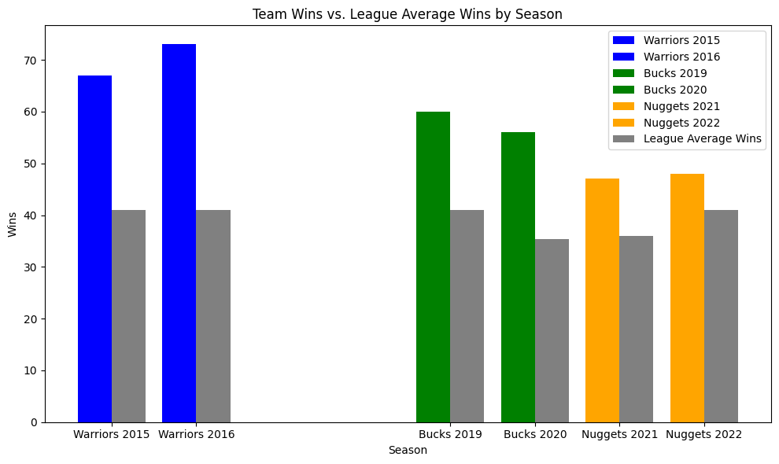

```python
# Combining the mean wins and losses dataframes for the MVPs
wbn_mean_wins_losses = pd.merge(warriors_mean_wins_losses, bucks_mean_wins_losses, how='outer', left_index=True, right_index=True)
wbn_mean_wins_losses = pd.merge(wbn_mean_wins_losses, nuggets_mean_wins_losses, how='outer', left_index=True, right_index=True)

# Summing up the wins across different columns ('w_x', 'w_y', 'w')
wbn_mean_wins_losses['wbn_wins'] = wbn_mean_wins_losses[['w_x', 'w_y', 'w']].sum(axis=1)

team_labels = ['Warriors 2015', 'Warriors 2016', 'Bucks 2019', 'Bucks 2020', 'Nuggets 2021', 'Nuggets 2022']

# Calculate league average wins
league_avg_wins = team_summary_df[team_summary_df['season'].isin(SGJ_MVP_seasons)].groupby('season')['w'].mean()

# Plotting
plt.figure(figsize=(10, 6))
plt.bar(league_avg_wins.index, league_avg_wins, width=0.4, label='League Average Wins', color='gray', align='edge')
plt.bar(wbn_mean_wins_losses.index, wbn_mean_wins_losses['wbn_wins'], width=-0.4, label=team_labels, tick_label=team_labels, color=['blue', 'blue', 'green', 'green', 'orange', 'orange'], align='edge')
plt.xlabel('Season')
plt.xticks(list(wbn_mean_wins_losses.index))
plt.ylabel('Wins')
plt.title('Team Wins vs. League Average Wins by Season')
plt.legend()
plt.tight_layout()
plt.show()
```

Beyond the players individual statistics, this goes to show that the MVP's team performs far better than the average NBA team that season.

## Model Questions

Throughout the EDAs we've explored various statistics beyond shooting metrics to understand what makes an MVP-caliber player. Specifically, we've explored rebounds per game and assists per game to gain insights into players like Giannis Antetokounmpo and Nikola Jokic, who do not excel in shooting like Stephen Curry but are impactful in other areas of the game. We've futher explored team perfomance metrics to understand the context of MVP seasons within the success of the players' teams. Given this analysis, here are two plausible models to consider:

### Model 1: Predicitng MVP Winners Based on Player Performance Metrics

**Independent Variables (Features)**: player statistics like points per game, rebounds per game, assists per game, shooting percentages, and advanced metrics such as player efficiency rating

**Dependent Variable (Target)**: MVP award status

**Methodology**: regression, decision trees, or random forests to predict whether a player will win MVP award based on performance metrics. This model will help identify which player statistics are most strongly associated with winning the MVP award.

### Model 2: Predicting Team Success Based on Player and Team Performance Metrics

**Independent Variables (Features)**: Player performance metrics and team performance metrics (team wins, offensive rating, defensive rating)

**Dependent Variable (Target)**: Team Success (e.g. playoff appearance [MVP is a regular season award but they are considered a good team if regular season performance leads to a playoff berth], team wins compared to average team wins)

**Methodology**: Regression techniques such as linear regression or gradient boosting to predict team success based on combination of player and team performance metrics. This model will help identify key factors contributing to team's success, including impact of MVP-caliber players.

# Generating Models (Milestone 3 Starts Here)

## More Data, More Preprocessing

### Data Importing

For our model exploration, we're going to look at some more data and try to create some models to explore the important features that make up an MVP.

```python
# Let's import some more data frames and begin exploring the NBA season awards

# We already have combined player per game and player shooting stats, and team summary stats available to us.

# File paths for new data we will use
advanced_file_path = 'Data Sets/NBA Stats (1947-Present)/Advanced.csv'
award_file_path = 'Data Sets/NBA Stats (1947-Present)/Player Award Shares.csv'

# Creating dataframes for the new data
advanced_df = pd.read_csv(advanced_file_path)
awards_df = pd.read_csv(award_file_path)

# Let's look at awards
awards_df.head()
```

|  | season | award | player | age | tm | first | pts_won | pts_max | share | winner | seas_id | player_id |
| --- | --- | --- | --- | --- | --- | --- | --- | --- | --- | --- | --- | --- |
| 0 | 2023 | dpoy | Jaren Jackson Jr. | 23 | MEM | 56.0 | 391.0 | 500.0 | 0.782 | True | 30733 | 4632 |
| 1 | 2023 | dpoy | Brook Lopez | 34 | MIL | 31.0 | 309.0 | 500.0 | 0.618 | False | 30508 | 3801 |
| 2 | 2023 | dpoy | Evan Mobley | 21 | CLE | 8.0 | 101.0 | 500.0 | 0.202 | False | 30640 | 4931 |
| 3 | 2023 | dpoy | Draymond Green | 32 | GSW | 3.0 | 34.0 | 500.0 | 0.068 | False | 30622 | 4085 |
| 4 | 2023 | dpoy | Bam Adebayo | 25 | MIA | 1.0 | 18.0 | 500.0 | 0.036 | False | 30489 | 4472 |

As we can see, in this new awards dataframe, award winners are determined by two columns: award and winner. We can determine the who the actual award winner was that season when the winner is True. Since it is originally in the dataframe as an object, we want to convert the value of winner into a boolean and make a new dataframe from it.

```python
# Convert 'winner' column to boolean type and create a winners dataframe
award_winner_df = awards_df[awards_df['winner'].astype(bool) == True]
award_winner_df.head()
```

|  | season | award | player | age | tm | first | pts_won | pts_max | share | winner | seas_id | player_id |
| --- | --- | --- | --- | --- | --- | --- | --- | --- | --- | --- | --- | --- |
| 0 | 2023 | dpoy | Jaren Jackson Jr. | 23 | MEM | 56.0 | 391.0 | 500.0 | 0.782 | True | 30733 | 4632 |
| 12 | 2023 | mip | Lauri Markkanen | 25 | UTA | 69.0 | 430.0 | 500.0 | 0.860 | True | 30871 | 4535 |
| 25 | 2023 | nba mvp | Joel Embiid | 28 | PHI | 73.0 | 915.0 | 1000.0 | 0.915 | True | 30764 | 4417 |
| 38 | 2023 | nba roy | Paolo Banchero | 20 | ORL | 98.0 | 494.0 | 500.0 | 0.988 | True | 30981 | 5089 |
| 44 | 2023 | smoy | Malcolm Brogdon | 30 | BOS | 60.0 | 408.0 | 500.0 | 0.816 | True | 30890 | 4424 |

Now we can create a new dataframe that shows past season MVPs!

```python
past_MVPs = award_winner_df[award_winner_df['award'] == 'nba mvp']
past_MVPs.head()
```

|  | season | award | player | age | tm | first | pts_won | pts_max | share | winner | seas_id | player_id |
| --- | --- | --- | --- | --- | --- | --- | --- | --- | --- | --- | --- | --- |
| 25 | 2023 | nba mvp | Joel Embiid | 28 | PHI | 73.0 | 915.0 | 1000.0 | 0.915 | True | 30764 | 4417 |
| 77 | 2022 | nba mvp | Nikola Jokić | 26 | DEN | 65.0 | 875.0 | 1000.0 | 0.875 | True | 30247 | 4352 |
| 145 | 2021 | nba mvp | Nikola Jokić | 25 | DEN | 91.0 | 971.0 | 1010.0 | 0.961 | True | 29456 | 4352 |
| 206 | 2020 | nba mvp | Giannis Antetokounmpo | 25 | MIL | 85.0 | 962.0 | 1010.0 | 0.952 | True | 28507 | 4164 |
| 267 | 2019 | nba mvp | Giannis Antetokounmpo | 24 | MIL | 78.0 | 941.0 | 1010.0 | 0.932 | True | 27809 | 4164 |

### Data Merging

Now let's go ahead and create a big dataframe to use for our model!

```python
# Using our newly imported awards data and adding it to our combined player per game and player shooting dataframe
ppg_ps_combined_df = pd.merge(ppg_ps_combined_df, award_winner_df[['player', 'season', 'award', 'pts_won', 'first', 'pts_max', 'share', 'winner']], on=['player', 'season'], how='left')
```

```python
# Looking at the winners
ppg_ps_combined_df[ppg_ps_combined_df['winner'] == True].head()
```

|  | seas_id | season | player_id | player | pos | age | experience | lg | tm | g | gs | mp_per_game | fg_per_game | fga_per_game | fg_percent_per_game | x3p_per_game | x3pa_per_game | x3p_percent | x2p_per_game | x2pa_per_game | x2p_percent | e_fg_percent | ft_per_game | fta_per_game | ft_percent | orb_per_game | drb_per_game | trb_per_game | ast_per_game | … |
| --- | --- | --- | --- | --- | --- | --- | --- | --- | --- | --- | --- | --- | --- | --- | --- | --- | --- | --- | --- | --- | --- | --- | --- | --- | --- | --- | --- | --- | --- | --- |
| 957 | 30733 | 2023 | 4632 | Jaren Jackson Jr. | C | 23.0 | 5 | NBA | MEM | 63 | 63.0 | 28.4 | 6.6 | 13.0 | 0.506 | 1.6 | 4.5 | 0.355 | 5.0 | 8.6 | 0.585 | 0.567 | 3.8 | 4.9 | 0.788 | 1.7 | 5.0 | 6.8 | 1.0 | … |
| 986 | 30764 | 2023 | 4417 | Joel Embiid | C | 28.0 | 7 | NBA | PHI | 66 | 66.0 | 34.6 | 11.0 | 20.1 | 0.548 | 1.0 | 3.0 | 0.330 | 10.0 | 17.1 | 0.587 | 0.573 | 10.0 | 11.7 | 0.857 | 1.7 | 8.4 | 10.2 | 4.2 | … |
| 1092 | 30871 | 2023 | 4535 | Lauri Markkanen | SF | 25.0 | 6 | NBA | UTA | 66 | 66.0 | 34.4 | 8.7 | 17.3 | 0.499 | 3.0 | 7.7 | 0.391 | 5.6 | 9.6 | 0.585 | 0.586 | 5.3 | 6.0 | 0.875 | 2.0 | 6.7 | 8.6 | 1.9 | … |
| 1111 | 30890 | 2023 | 4424 | Malcolm Brogdon | PG | 30.0 | 7 | NBA | BOS | 67 | 0.0 | 26.0 | 5.3 | 10.9 | 0.484 | 2.0 | 4.4 | 0.444 | 3.3 | 6.5 | 0.510 | 0.574 | 2.4 | 2.7 | 0.870 | 0.6 | 3.6 | 4.2 | 3.7 | … |
| 1203 | 30981 | 2023 | 5089 | Paolo Banchero | PF | 20.0 | 1 | NBA | ORL | 72 | 72.0 | 33.8 | 6.7 | 15.6 | 0.427 | 1.2 | 4.0 | 0.298 | 5.5 | 11.6 | 0.471 | 0.465 | 5.5 | 7.4 | 0.738 | 1.2 | 5.7 | 6.9 | 3.7 | … |

```python
ppg_ps_combined_df.columns.unique()
```

```
Index(['seas_id', 'season', 'player_id', 'player', 'pos', 'age', 'experience', 'lg', 'tm', 'g',
       'gs', 'mp_per_game', 'fg_per_game', 'fga_per_game', 'fg_percent_per_game', 'x3p_per_game',
       'x3pa_per_game', 'x3p_percent', 'x2p_per_game', 'x2pa_per_game', 'x2p_percent',
       'e_fg_percent', 'ft_per_game', 'fta_per_game', 'ft_percent', 'orb_per_game', 'drb_per_game',
       'trb_per_game', 'ast_per_game', 'stl_per_game', 'blk_per_game', 'tov_per_game',
       'pf_per_game', 'pts_per_game', 'mp', 'fg_percent', 'avg_dist_fga',
       'percent_fga_from_x2p_range', 'percent_fga_from_x0_3_range', 'percent_fga_from_x3_10_range',
       'percent_fga_from_x10_16_range', 'percent_fga_from_x16_3p_range',
       'percent_fga_from_x3p_range', 'fg_percent_from_x2p_range', 'fg_percent_from_x0_3_range',
       'fg_percent_from_x3_10_range', 'fg_percent_from_x10_16_range',
       'fg_percent_from_x16_3p_range', 'fg_percent_from_x3p_range', 'percent_assisted_x2p_fg',
       'percent_assisted_x3p_fg', 'percent_dunks_of_fga', 'num_of_dunks',
       'percent_corner_3s_of_3pa', 'corner_3_point_percent', 'num_heaves_attempted',
       'num_heaves_made', 'fg', 'fga', 'fg_percent_totals', 'x3p', 'x3pa', 'x3p_percent_totals',
       'x2p', 'x2pa', 'x2p_percent_totals', 'e_fg_percent_totals', 'ft', 'fta',
       'ft_percent_totals', 'orb', 'drb', 'trb', 'ast', 'stl', 'blk', 'tov', 'pf', 'pts', 'award',
       'pts_won', 'first', 'pts_max', 'share', 'winner'],
      dtype='object')
```

Now let's add a win percentage to our team stats from our earlier exploration and combine the data before introducing the advanced stats to the data as well.

```python
# Adding win percentage
team_summary_df['win_percentage'] = team_summary_df['w'] / (team_summary_df['w'] + team_summary_df['l'])


# Renaming stats that are reflected in both dataframes
ppg_ps_combined_df.rename(columns={
    'orb_per_game': 'player_orb_per_game',
    'drb_per_game': 'player_drb_per_game',
    'e_fg_percent': 'player_e_fg_percent',
    'tov_per_game': 'player_tov_per_game',
    'x3p_per_game': 'player_x3p_per_game',
    'ft_per_game': 'player_ft_per_game'
}, inplace=True)

team_summary_df.rename(columns={
    'orb_percent': 'team_orb_percent',
    'drb_percent': 'team_drb_percent',
    'e_fg_percent': 'team_e_fg_percent',
    'tov_percent': 'team_tov_percent',
    'x3p_ar': 'team_x3p_ar',
    'ft_fga': 'team_free_throws_per_field_goal_attempt',
    'opp_drb_percent': 'team_opp_drb_percent',
    'win_perc': 'team_win_percentage',
    'w': 'team_wins',
    'l': 'team_losses',
    'pw': 'team_pythagorean_wins',
    'pl': 'team_pythagorean_losses',
    'mov': 'team_margin_of_victory',
    'sos': 'team_strength_of_schedule',
    'srs': 'team_simple_rating_system',
    'o_rtg': 'team_offensive_rating',
    'd_rtg': 'team_defensive_rating',
    'n_rtg': 'team_net_rating',
    'pace': 'team_pace',
    'f_tr': 'team_free_throw_rate',
    'ts_percent': 'team_true_shooting_percentage',
    'opp_e_fg_percent': 'team_opponent_efg_percent',
    'opp_tov_percent': 'team_opponent_tov_percent'
}, inplace=True)

# Combining the dataframes into team_player_stats
team_player_stats_df = pd.merge(ppg_ps_combined_df, team_summary_df, how='left', left_on=['season', 'tm'], right_on=['season', 'abbreviation'], suffixes=('_playerStat', '_teamStat'))
```

```python
# Selecting relevant columns from advanced stats and renaming them to then merge into team_player_stats
columns_to_keep = [
    'season', 'player', 'per', 'ts_percent', 'x3p_ar', 'f_tr', 'orb_percent',
    'drb_percent', 'trb_percent', 'ast_percent', 'stl_percent', 'blk_percent',
    'tov_percent', 'usg_percent', 'ows', 'dws', 'ws', 'ws_48', 'obpm', 'dbpm',
    'bpm', 'vorp'
]

advanced_df = advanced_df[columns_to_keep].copy()

advanced_df.rename(columns={
                   'per': 'player_per',
                   'ts_percent': 'player_ts_percent',
                   'x3p_ar': 'player_x3p_ar',
                   'f_tr': 'player_f_tr',
                   'orb_percent': 'player_orb_percent',
                   'drb_percent': 'player_drb_percent',
                   'trb_percent': 'player_trb_percent',
                   'ast_percent': 'player_ast_percent',
                   'stl_percent': 'player_stl_percent',
                   'blk_percent': 'player_blk_percent',
                   'tov_percent': 'player_tov_percent',
                   'usg_percent': 'player_usg_percent',
                   'ows': 'player_ows',
                   'dws': 'player_dws',
                   'ws': 'player_ws',
                   'ws_48': 'player_ws_48',
                   'obpm': 'player_obpm',
                   'dbpm': 'player_dbpm',
                   'bpm': 'player_bpm',
                   'vorp': 'player_vorp'
    }, inplace=True)

team_player_stats_df = pd.merge(team_player_stats_df, advanced_df, on=['player', 'season'], how='left')

# Making sure all of our data is consistent in being after 1980 and dropping anything not in the NBA
modern_data = team_player_stats_df[(team_player_stats_df['season'] >= 1980) & (team_player_stats_df['lg_teamStat'] == 'NBA')].copy()

# Taking a look at our mega dataframe!
modern_data.head()
```

|  | seas_id | season | player_id | player | pos | age_playerStat | experience | lg_playerStat | tm | g | gs | mp_per_game | fg_per_game | fga_per_game | fg_percent_per_game | player_x3p_per_game | x3pa_per_game | x3p_percent | x2p_per_game | x2pa_per_game | x2p_percent | player_e_fg_percent | player_ft_per_game | fta_per_game | ft_percent | player_orb_per_game | player_drb_per_game | trb_per_game | ast_per_game | … |
| --- | --- | --- | --- | --- | --- | --- | --- | --- | --- | --- | --- | --- | --- | --- | --- | --- | --- | --- | --- | --- | --- | --- | --- | --- | --- | --- | --- | --- | --- | --- |
| 0 | 31136 | 2024 | 5025 | A.J. Green | SG | 24.0 | 2 | NBA | MIL | 39 | 0.0 | 9.2 | 1.4 | 3.3 | 0.438 | 1.2 | 2.8 | 0.423 | 0.2 | 0.4 | 0.529 | 0.621 | 0.2 | 0.2 | 1.000 | 0.2 | 0.9 | 1.0 | 0.5 | … |
| 1 | 31137 | 2024 | 5026 | A.J. Lawson | SG | 23.0 | 2 | NBA | DAL | 28 | 0.0 | 8.3 | 1.4 | 3.0 | 0.471 | 0.5 | 1.4 | 0.325 | 1.0 | 1.6 | 0.600 | 0.547 | 0.4 | 0.7 | 0.632 | 0.4 | 0.8 | 1.2 | 0.5 | … |
| 2 | 31138 | 2024 | 5027 | AJ Griffin | SF | 20.0 | 2 | NBA | ATL | 18 | 0.0 | 7.3 | 0.7 | 2.5 | 0.289 | 0.5 | 1.8 | 0.273 | 0.2 | 0.7 | 0.333 | 0.389 | 0.1 | 0.1 | 1.000 | 0.1 | 0.7 | 0.8 | 0.2 | … |
| 3 | 31139 | 2024 | 4219 | Aaron Gordon | PF | 28.0 | 10 | NBA | DEN | 54 | 54.0 | 31.5 | 5.5 | 9.8 | 0.557 | 0.5 | 1.8 | 0.293 | 4.9 | 8.0 | 0.618 | 0.585 | 2.4 | 3.7 | 0.652 | 2.4 | 4.1 | 6.5 | 3.2 | … |
| 4 | 31140 | 2024 | 4582 | Aaron Holiday | PG | 27.0 | 6 | NBA | HOU | 56 | 1.0 | 17.3 | 2.5 | 5.5 | 0.455 | 1.2 | 3.0 | 0.410 | 1.3 | 2.6 | 0.507 | 0.565 | 0.7 | 0.8 | 0.889 | 0.3 | 1.4 | 1.7 | 1.8 | … |

```python
# Checking existing column names and their count before drop
print("Columns before drop:", modern_data.columns)
print("Number of columns before drop:", len(modern_data.columns))
```

```
Columns before drop: Index(['seas_id', 'season', 'player_id', 'player', 'pos', 'age_playerStat', 'experience',
       'lg_playerStat', 'tm', 'g',
       ...
       'player_tov_percent', 'player_usg_percent', 'player_ows', 'player_dws', 'player_ws',
       'player_ws_48', 'player_obpm', 'player_dbpm', 'player_bpm', 'player_vorp'],
      dtype='object', length=136)
Number of columns before drop: 136
```

```python
# Dropping some data to clean it up a bit

# Drop columns
modern_data.drop(columns=['lg_playerStat', 'tm', 'lg_teamStat', 'arena', 'attend', 'attend_g', 'e_fg_percent_totals'], inplace=True, errors='ignore')
modern_data.dropna(subset=['win_percentage', 'abbreviation'], inplace=True)

# Check remaining column names and their count after drop
print("Columns after drop:", modern_data.columns)
print("Number of columns after drop:", len(modern_data.columns))
```

```
Columns after drop: Index(['seas_id', 'season', 'player_id', 'player', 'pos', 'age_playerStat', 'experience', 'g',
       'gs', 'mp_per_game',
       ...
       'player_tov_percent', 'player_usg_percent', 'player_ows', 'player_dws', 'player_ws',
       'player_ws_48', 'player_obpm', 'player_dbpm', 'player_bpm', 'player_vorp'],
      dtype='object', length=129)
Number of columns after drop: 129
```

## Exploring Model Data

Now let's do some quick visualizations from the data frame we will use for our model!

### Model Data Breakdown

Before we continue, here is a breakdown of the data we will be using.

Player-Specific Statistics:

- **seas_id, season, player_id**: Identifiers for the season and player.
- **player**: Player's name.
- **pos**: Player’s position.
- **age_playerStat**: Player’s age.
- **experience**: Years of experience in the league.
- **g, gs**: Games played and games started.
- **mp_per_game**: Minutes per game.
- **fg_per_game, fga_per_game, fg_percent_per_game**: Field goals made, attempted, and field goal percentage per game.
- **player_x3p_per_game, x3pa_per_game, x3p_percent**: Three-point shots made, attempted, and percentage.
- **x2p_per_game, x2pa_per_game, x2p_percent**: Two-point shots made, attempted, and percentage.
- **player_e_fg_percent**: Effective field goal percentage (accounts for 3-pointers being worth more).
- **player_ft_per_game, fta_per_game, ft_percent**: Free throws made, attempted, and free throw percentage.
- **player_orb_per_game, player_drb_per_game, trb_per_game**: Offensive, defensive, and total rebounds per game.
- **ast_per_game, stl_per_game, blk_per_game**: Assists, steals, and blocks per game.
- **player_tov_per_game, pf_per_game, pts_per_game**: Turnovers, personal fouls, and points per game.

Shooting Details:

- **fg, fga, fg_percent**: Total field goals made, attempted, and percentage.
- **x3p, x3pa, x3p_percent**: Total three-pointers made, attempted, and percentage.
- **x2p, x2pa, x2p_percent**: Total two-pointers made, attempted, and percentage.
- **ft, fta, ft_percent**: Free throws made, attempted, and percentage.
- **orb, drb, trb, ast, stl, blk, tov, pf, pts**: Total counts of rebounds, assists, steals, blocks, turnovers, personal fouls, and points.
- **Detailed shooting statistics regarding percentages from various distances and assisted shot details**.

Advanced Metrics:

- **player_per, player_ts_percent, player_x3p_ar, player_f_tr**: Player efficiency rating, true shooting percentage, three-point attempt rate, and free throw rate.
- **player_orb_percent, player_drb_percent, player_trb_percent**: Rebound percentages.
- **player_ast_percent, player_stl_percent, player_blk_percent, player_tov_percent, player_usg_percent**: Percentages indicating assist, steal, block, turnover rates, and usage percentage.
- **player_ows, player_dws, player_ws, player_ws_48**: Offensive, defensive, and total win shares, and win shares per 48 minutes.
- **player_obpm, player_dbpm, player_bpm, player_vorp**: Box plus/minus statistics and value over replacement player.

Team Statistics:

- **team, abbreviation**: Team name and abbreviation.
- **playoffs, age_teamStat**: Indicates whether the team made the playoffs and average age of the team.
- **team_wins, team_losses**: Total wins and losses.
- **team_pythagorean_wins, team_pythagorean_losses, team_margin_of_victory, team_strength_of_schedule, team_simple_rating_system**: Estimated wins and losses based on scoring margin, strength of schedule, and other metrics.
- **team_offensive_rating, team_defensive_rating, team_net_rating**: Team’s offensive, defensive, and net ratings.
- **team_pace, team_free_throw_rate, team_x3p_ar, team_true_shooting_percentage, team_e_fg_percent, team_tov_percent**: Pace of play, free throw and three-point attempt rates, true shooting, effective field goal, and turnover percentages.
- **team_orb_percent, team_free_throws_per_field_goal_attempt, team_opponent_efg_percent, team_opponent_tov_percent, team_opp_drb_percent, opp_ft_fga**: Rebounding rates, free throws per field goal attempt, opponent's shooting efficiency, and turnover rates.
- **win_percentage**: The winning percentage of the team.

Award Details (if applicable):

- **award, pts_won, first, pts_max, share, winner**: Award-related details including points won, first-place votes, maximum points possible, share of total votes, and whether they won.

### Model Data Visual Exploration

Now we can look at some cool visualizations for our data before making a model!

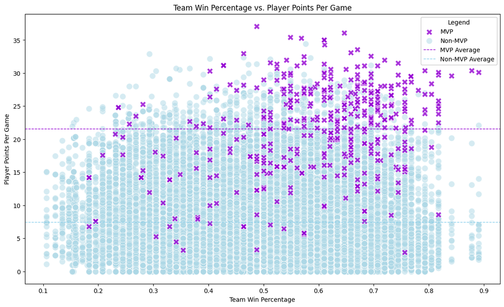

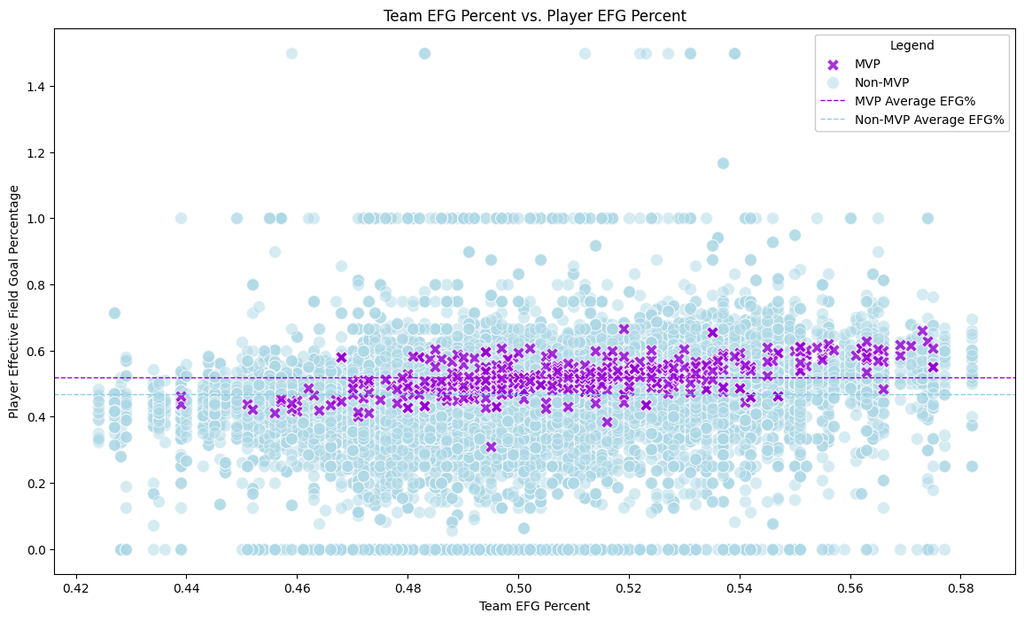

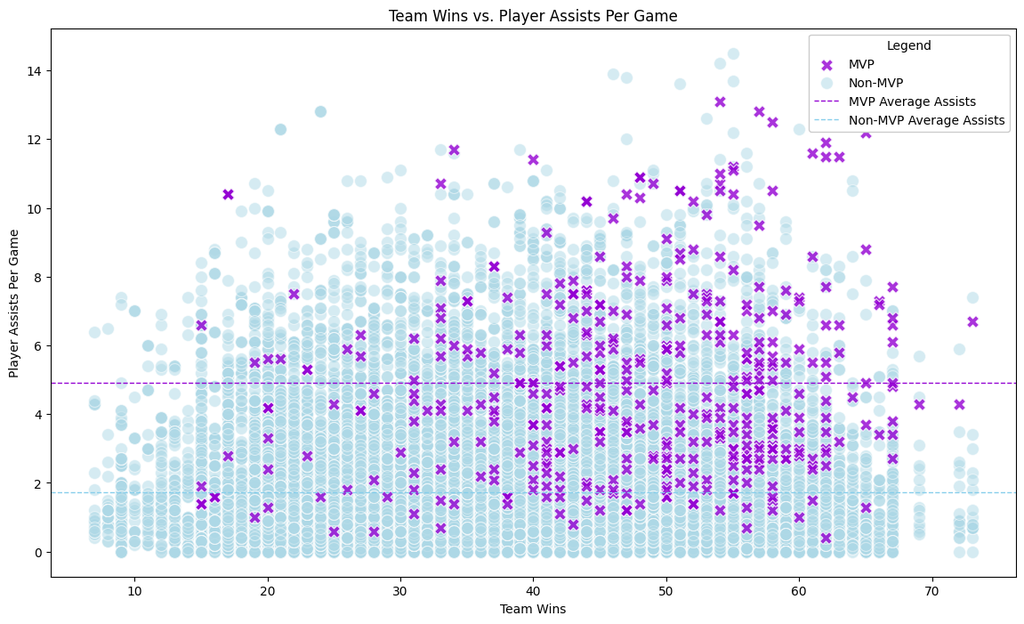

```python
# Updating past_MVPs data frame
past_MVPs = modern_data[modern_data['award'] == 'nba mvp']

# Add a new column 'Is_MVP' to modern_data dataframe
modern_data['Is_MVP'] = modern_data['player'].isin(past_MVPs['player'])

# Visualization 1: Team Win Percentage vs. Player Points Per Game
plt.figure(figsize=(14, 8))
sns.scatterplot(data=modern_data[modern_data['Is_MVP'] == False], x="win_percentage", y="pts_per_game", color='lightblue', marker='o', s=100, alpha=0.5, zorder = 1, label='Non-MVP')
sns.scatterplot(data=modern_data[modern_data['Is_MVP'] == True], x="win_percentage", y="pts_per_game", color='darkviolet', marker='X', s=100, alpha=.8, zorder = 2, label='MVP')
plt.axhline(modern_data[modern_data['Is_MVP'] == True]['pts_per_game'].mean(), color='darkviolet', linestyle='--', linewidth=1, label='MVP Average')
plt.axhline(modern_data[modern_data['Is_MVP'] == False]['pts_per_game'].mean(), color='skyblue', linestyle='--', linewidth=1, label='Non-MVP Average')
plt.title('Team Win Percentage vs. Player Points Per Game')
plt.xlabel('Team Win Percentage')
plt.ylabel('Player Points Per Game')
handles, labels = plt.gca().get_legend_handles_labels()
order = [1, 0, 2, 3]
plt.legend([handles[idx] for idx in order], [labels[idx] for idx in order], title='Legend', loc='upper right', framealpha=1)
plt.show()

# Visualization 2: Team EFG Percent vs. Player EFG Percent
plt.figure(figsize=(14, 8))
sns.scatterplot(data=modern_data[modern_data['Is_MVP'] == False], x="team_e_fg_percent", y="player_e_fg_percent", color='lightblue', marker='o', s=100, alpha=0.5, zorder = 1, label='Non-MVP')
sns.scatterplot(data=modern_data[modern_data['Is_MVP'] == True], x="team_e_fg_percent", y="player_e_fg_percent", color='darkviolet', marker='X', s=100, alpha=.8, zorder = 2, label='MVP')
plt.axhline(modern_data[modern_data['Is_MVP'] == True]['player_e_fg_percent'].mean(), color='darkviolet', linestyle='--', linewidth=1, label='MVP Average EFG%')
plt.axhline(modern_data[modern_data['Is_MVP'] == False]['player_e_fg_percent'].mean(), color='skyblue', linestyle='--', linewidth=1, label='Non-MVP Average EFG%')
plt.title('Team EFG Percent vs. Player EFG Percent')
plt.xlabel('Team EFG Percent')
plt.ylabel('Player Effective Field Goal Percentage')
handles, labels = plt.gca().get_legend_handles_labels()
order = [1, 0, 2, 3]
plt.legend([handles[idx] for idx in order], [labels[idx] for idx in order], title='Legend', loc='upper right', framealpha=1)
plt.show()

# Visualization 3: Player Assists Per Game vs. Team Wins
plt.figure(figsize=(14, 8))
sns.scatterplot(data=modern_data[modern_data['Is_MVP'] == False], x="team_wins", y="ast_per_game", color='lightblue', marker='o', s=100, alpha=0.5, zorder = 1, label='Non-MVP')
sns.scatterplot(data=modern_data[modern_data['Is_MVP'] == True], x="team_wins", y="ast_per_game", color='darkviolet', marker='X', s=100, alpha=.8, zorder = 2, label='MVP')
plt.axhline(modern_data[modern_data['Is_MVP'] == True]['ast_per_game'].mean(), color='darkviolet', linestyle='--', linewidth=1, label='MVP Average Assists')
plt.axhline(modern_data[modern_data['Is_MVP'] == False]['ast_per_game'].mean(), color='skyblue', linestyle='--', linewidth=1, label='Non-MVP Average Assists')
plt.title('Team Wins vs. Player Assists Per Game')
plt.xlabel('Team Wins')
plt.ylabel('Player Assists Per Game')
handles, labels = plt.gca().get_legend_handles_labels()
order = [1, 0, 2, 3]
plt.legend([handles[idx] for idx in order], [labels[idx] for idx in order], title='Legend', loc='upper right', framealpha=1)
plt.show()
```

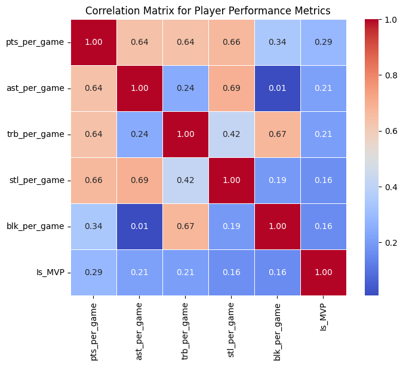

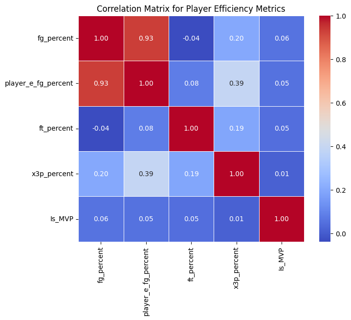

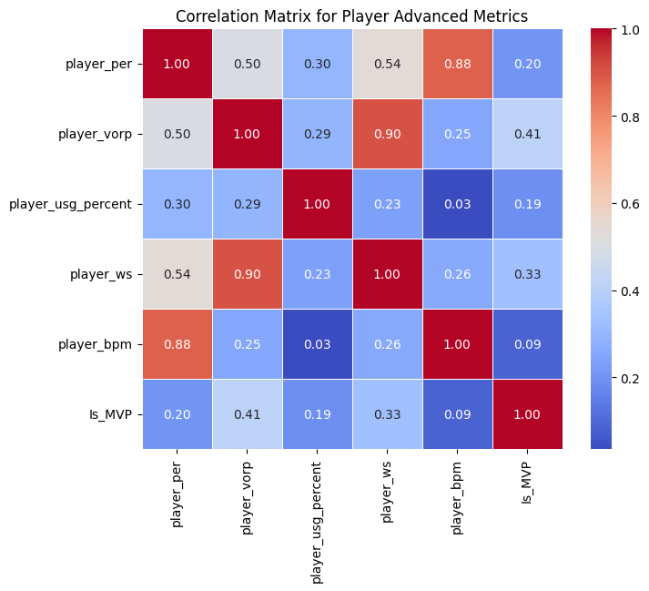

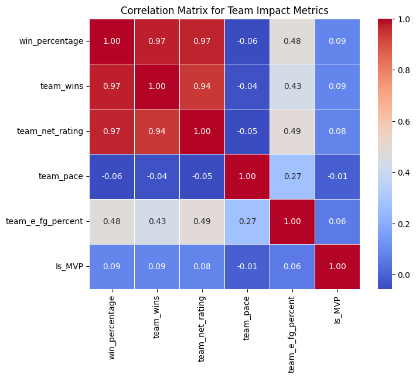

```python
# Now let's show a few correlation matrices for different categories of stats

# Subsets of performance-related statistics, advanced metrics, efficiency-related statistics, and team impact-related statistics
performance_stats = modern_data[['pts_per_game', 'ast_per_game', 'trb_per_game', 'stl_per_game', 'blk_per_game', 'Is_MVP']]
advanced_stats = modern_data[['player_per', 'player_vorp', 'player_usg_percent', 'player_ws', 'player_bpm', 'Is_MVP']]
efficiency_stats = modern_data[['fg_percent', 'player_e_fg_percent', 'ft_percent', 'x3p_percent', 'Is_MVP']]
team_impact_stats = modern_data[['win_percentage', 'team_wins', 'team_net_rating', 'team_pace', 'team_e_fg_percent', 'Is_MVP']]

# Computing the correlation matrices for these stats
corr_performance = performance_stats.corr()
corr_advanced = advanced_stats.corr()
corr_efficiency = efficiency_stats.corr()
corr_team_impact = team_impact_stats.corr()

# Plotting the correlation matrices
plt.figure(figsize=(8, 6))
sns.heatmap(corr_performance, annot=True, fmt=".2f", cmap='coolwarm', cbar=True, square=True, linewidths=.5)
plt.title('Correlation Matrix for Player Performance Metrics')
plt.show()

plt.figure(figsize=(8, 6))
sns.heatmap(corr_efficiency, annot=True, fmt=".2f", cmap='coolwarm', cbar=True, square=True, linewidths=.5)
plt.title('Correlation Matrix for Player Efficiency Metrics')
plt.show()

plt.figure(figsize=(8, 6))
sns.heatmap(corr_advanced, annot=True, fmt=".2f", cmap='coolwarm', cbar=True, square=True, linewidths=.5)
plt.title('Correlation Matrix for Player Advanced Metrics')
plt.show()

plt.figure(figsize=(8, 6))
sns.heatmap(corr_team_impact, annot=True, fmt=".2f", cmap='coolwarm', cbar=True, square=True, linewidths=.5)
plt.title('Correlation Matrix for Team Impact Metrics')
plt.show()
```

## Building a Base Model!

Finally, let's start building our model! We will start with a base model before trying to improve it.

```python
from sklearn.model_selection import train_test_split
from sklearn.preprocessing import StandardScaler
from sklearn.impute import SimpleImputer
from sklearn.linear_model import LogisticRegression
from sklearn.pipeline import Pipeline
from sklearn.metrics import classification_report, accuracy_score, confusion_matrix, roc_curve, roc_auc_score, precision_recall_curve, auc
import matplotlib.pyplot as plt
import pandas as pd

modern_data['Is_MVP'] = modern_data['Is_MVP'].astype(int)

# Define features and target for the base model
base_features = [
    'pts_per_game', 'trb_per_game', 'ast_per_game', 'stl_per_game', 'blk_per_game',
    'fg_percent_per_game', 'player_e_fg_percent', 'ft_percent', 'x3p_percent',
    'player_per', 'player_vorp', 'player_ws', 'player_bpm',
    'team_wins', 'win_percentage', 'team_net_rating',
    'player_ts_percent', 'player_x3p_ar', 'player_usg_percent',
    'player_ows', 'player_dws', 'player_dbpm'
]
X_base = modern_data[base_features]
y_base = modern_data['Is_MVP']

# Create preprocessing and modeling pipeline
model_base = Pipeline([
    ('imputer', SimpleImputer(strategy='median')),
    ('scaler', StandardScaler()),
    ('classifier', LogisticRegression(max_iter=1000))
])

# Splitting data
X_train_base, X_test_base, y_train_base, y_test_base = train_test_split(X_base, y_base, test_size=0.2, random_state=42)

# Fitting model
model_base.fit(X_train_base, y_train_base)

# Making predictions
predictions_base = model_base.predict(X_test_base)

# Evaluating model
print("Base Model Accuracy:", accuracy_score(y_test_base, predictions_base))
print(classification_report(y_test_base, predictions_base))
```

```
Base Model Accuracy: 0.9887554306158958
              precision    recall  f1-score   support

           0       0.99      1.00      0.99      7712
           1       0.73      0.36      0.48       114

    accuracy                           0.99      7826
   macro avg       0.86      0.68      0.74      7826
weighted avg       0.99      0.99      0.99      7826
```

Let's discuss some of these results. The model has a high accuracy at 98.88% indicating it generally predicts well, but coupled with the precision, recall, and F1-score for MVP prediction, there are some issues. Having a precision of 0.73 implies that the model is about 73% accurate when it does predict a player to be the MVP. The recall of 0.36 indicates that the model misses on a good amount of true MVPs. The F1-score indicates that it is not quite as effective at predicting MVPs to non-MVPs. The model's overall accuracy is skewed by its ability to correctly predict the majority class (non-MVPs), which are much more common than the MVP class. The model struggles more with the minority class (MVPs), as evidenced by the lower recall and F1-score. Let's try to use the model to make a prediction!

### Base Model 2023 MVP Prediction

```python
# Base Model 2023 MVP Prediction
data_2023_base = modern_data[modern_data['season'] == 2023].copy()
X_2023_base = data_2023_base[base_features]
predictions_2023_base = model_base.predict(X_2023_base)
probs_2023_base = model_base.predict_proba(X_2023_base)[:, 1]
data_2023_base['predicted_MVP_base'] = predictions_2023_base
data_2023_base['MVP_probability_base'] = probs_2023_base
top_candidates_base = data_2023_base[data_2023_base['predicted_MVP_base'] == 1].sort_values('MVP_probability_base', ascending=False)
print(top_candidates_base[['player', 'MVP_probability_base']])
```

```
                     player  MVP_probability_base
1911           Nikola Jokić              0.981343
1414  Giannis Antetokounmpo              0.972390
1556            Joel Embiid              0.932235
1749            Luka Dončić              0.831246
1741           LeBron James              0.601394
1457              Ja Morant              0.599394
1542           Jayson Tatum              0.567255
1313       Domantas Sabonis              0.547751
1688           Kevin Durant              0.502502
```

The output shows that the model has identified several top candidates for the MVP title, with Nikola Jokić leading in probability, followed by other notable players like Giannis Antetokounmpo, Joel Embiid, and Luka Dončić. The actual NBA MVP in 2023 was Joel Embiid, so it's good to see his high probability ranking by the model! This indicates that our model is effective at identifying strong candidates for the MVP. Let's do some model evaluation!

### Base Model Evaluation

Now let's do some exploration into the base model's performance. We will also store our different model versions results for comparison later!

```
Confusion Matrix:
 [[865   4]
 [ 14   5]]
Classification Report:
               precision    recall  f1-score   support

           0       0.98      1.00      0.99       869
           1       0.56      0.26      0.36        19

    accuracy                           0.98       888
   macro avg       0.77      0.63      0.67       888
weighted avg       0.97      0.98      0.98       888
```

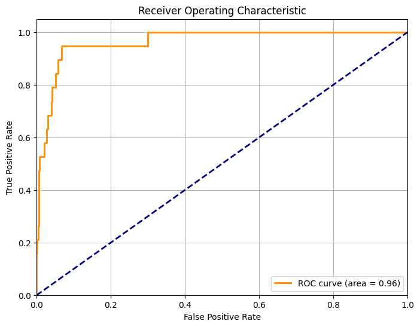

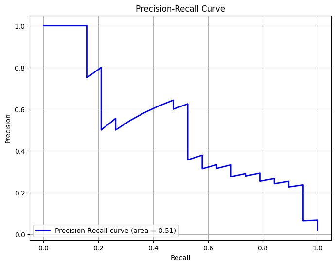

```python
# Dictionary to store metrics for each model version
model_metrics = {}

# DataFrame to summarize model evaluation metrics
columns = ['Model', 'Accuracy', 'ROC AUC', 'Precision_Non_MVP', 'Recall_Non_MVP', 'F1_Non_MVP', 'Precision_MVP', 'Recall_MVP', 'F1_MVP']
model_summary = pd.DataFrame(columns=columns)

# Model evaluation
y_true = data_2023_base['Is_MVP']
y_scores = probs_2023_base

# Confusion Matrix
conf_matrix = confusion_matrix(y_true, predictions_2023_base)
print("Confusion Matrix:\n", conf_matrix)

# Classification Report
class_report = classification_report(y_true, predictions_2023_base)
print("Classification Report:\n", class_report)

# ROC Curve and AUC
fpr, tpr, thresholds = roc_curve(y_true, y_scores)
roc_auc = auc(fpr, tpr)
plt.figure(figsize=(8, 6))
plt.plot(fpr, tpr, color='darkorange', lw=2, label='ROC curve (area = %0.2f)' % roc_auc)
plt.plot([0, 1], [0, 1], color='navy', lw=2, linestyle='--')
plt.grid(True)
plt.xlim([0.0, 1.0])
plt.ylim([0.0, 1.05])
plt.xlabel('False Positive Rate')
plt.ylabel('True Positive Rate')
plt.title('Receiver Operating Characteristic')
plt.legend(loc="lower right")
plt.show()

# Precision-Recall Curve
precision, recall, _ = precision_recall_curve(y_true, y_scores)
pr_auc = auc(recall, precision)
plt.figure(figsize=(8, 6))
plt.plot(recall, precision, color='blue', lw=2, label='Precision-Recall curve (area = %0.2f)' % pr_auc)
plt.grid(True)
plt.xlabel('Recall')
plt.ylabel('Precision')
plt.title('Precision-Recall Curve')
plt.legend(loc="lower left")
plt.show()

# Calculate accuracy
accuracy_base = accuracy_score(y_true, predictions_2023_base)

# Store results
model_metrics['Base_Model'] = {
    'Confusion_Matrix': conf_matrix,
    'Classification_Report': class_report,
    'ROC_AUC': roc_auc,
    'Precision_Recall_AUC': pr_auc
}


base_metrics = pd.DataFrame({
    'Model': ['Base_Model'],
    'Accuracy': [accuracy_base],
    'ROC AUC': [roc_auc]
})

# Use concat to add the new row to model_summary
model_summary = pd.concat([model_summary, base_metrics], ignore_index=True)
```

## Feature Engineering Our Model

Let's see if we can do some feature engineering to improve the model. We are gonna try adding Points Per Minute, some polynomial features, and other advanced stats to our data frame. Then we will predict the 2023 MVP again with the updated model, and evaluate the new model!

```python
modern_data['points_per_minute'] = modern_data['pts_per_game'] / modern_data['mp_per_game']
modern_data['efficiency_team_success'] = modern_data['player_per'] * modern_data['win_percentage']
modern_data['player_per_squared'] = modern_data['player_per'] ** 2
modern_data['player_vorp_cubed'] = modern_data['player_vorp'] ** 3
modern_data['player_team_points_share'] = modern_data['pts_per_game'] / modern_data.groupby('team')['pts_per_game'].transform('mean')
```

```python
# Updated features list with new engineered features
features_fe = base_features + ['points_per_minute', 'efficiency_team_success', 'player_per_squared']

X_fe = modern_data[features_fe]
y_fe = modern_data['Is_MVP']

# Create preprocessing and modeling pipeline again
model_fe = Pipeline([
    ('imputer', SimpleImputer(strategy='median')),
    ('scaler', StandardScaler()),
    ('classifier', LogisticRegression(max_iter=1000))
])

# Splitting the data again
X_train_fe, X_test_fe, y_train_fe, y_test_fe = train_test_split(X_fe, y_fe, test_size=0.2, random_state=42)

# Fitting the model again
model_fe.fit(X_train_fe, y_train_fe)

# Making predictions
predictions_fe = model_fe.predict(X_test_fe)

# Evaluating the model
print("Feature Engineering Model Accuracy:", accuracy_score(y_test_fe, predictions_fe))
print(classification_report(y_test_fe, predictions_fe))
```

```
Feature Engineering Model Accuracy: 0.989010989010989
              precision    recall  f1-score   support

           0       0.99      1.00      0.99      7712
           1       0.74      0.38      0.50       114

    accuracy                           0.99      7826
   macro avg       0.87      0.69      0.75      7826
weighted avg       0.99      0.99      0.99      7826
```

### Feature Engineered Model 2023 MVP Prediction

```python
# Feature Engineering for the 2023 data
data_2023_fe = modern_data[modern_data['season'] == 2023].copy()
data_2023_fe['points_per_minute'] = data_2023_fe['pts_per_game'] / data_2023_fe['mp_per_game']
data_2023_fe['efficiency_team_success'] = data_2023_fe['player_per'] * data_2023_fe['win_percentage']
data_2023_fe['player_per_squared'] = data_2023_fe['player_per'] ** 2
data_2023_fe['player_vorp_cubed'] = data_2023_fe['player_vorp'] ** 3
data_2023_fe['player_team_points_share'] = data_2023_fe['pts_per_game'] / data_2023_fe.groupby('team')['pts_per_game'].transform('mean')
X_2023_fe = data_2023_fe[features_fe]
predictions_2023_fe = model_fe.predict(X_2023_fe)
probs_2023_fe = model_fe.predict_proba(X_2023_fe)[:, 1]
data_2023_fe['predicted_MVP_fe'] = predictions_2023_fe
data_2023_fe['MVP_probability_fe'] = probs_2023_fe
top_candidates_fe = data_2023_fe[data_2023_fe['predicted_MVP_fe'] == 1].sort_values('MVP_probability_fe', ascending=False)
print(top_candidates_fe[['player', 'MVP_probability_fe']])
```

```
                     player  MVP_probability_fe
1414  Giannis Antetokounmpo            0.975176
1911           Nikola Jokić            0.967024
1556            Joel Embiid            0.918652
1749            Luka Dončić            0.694112
1457              Ja Morant            0.632326
1741           LeBron James            0.603599
1542           Jayson Tatum            0.556099
1688           Kevin Durant            0.509479
```

### Feature Engineered Model Evaluation

```
Confusion Matrix:
 [[866   3]
 [ 14   5]]
Classification Report:
               precision    recall  f1-score   support

           0       0.98      1.00      0.99       869
           1       0.62      0.26      0.37        19

    accuracy                           0.98       888
   macro avg       0.80      0.63      0.68       888
weighted avg       0.98      0.98      0.98       888
```

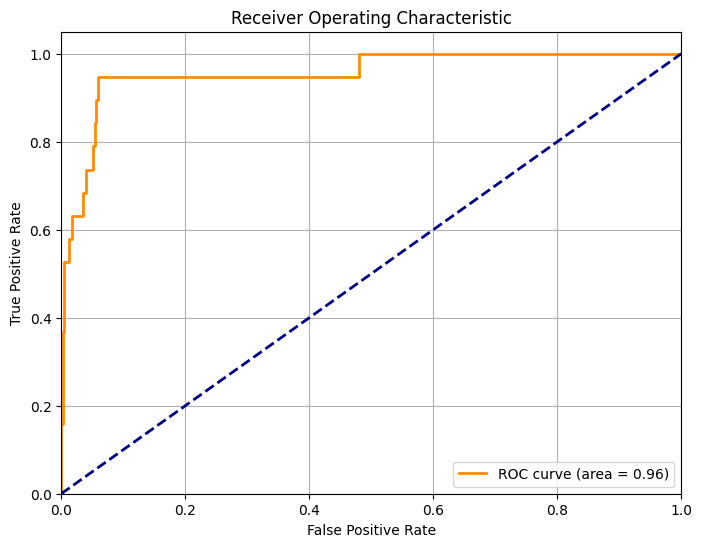

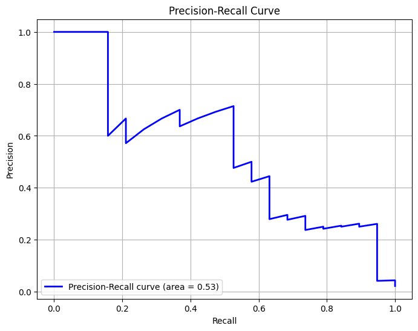

```python
# Model Evaluation
y_true_fe = data_2023_fe['Is_MVP']
y_scores_fe = probs_2023_fe

conf_matrix_fe = confusion_matrix(y_true_fe, predictions_2023_fe)
print("Confusion Matrix:\n", conf_matrix_fe)
class_report_fe = classification_report(y_true_fe, predictions_2023_fe)
print("Classification Report:\n", class_report_fe)

fpr_fe, tpr_fe, thresholds_fe = roc_curve(y_true_fe, y_scores_fe)
roc_auc_fe = auc(fpr_fe, tpr_fe)
plt.figure(figsize=(8, 6))
plt.plot(fpr_fe, tpr_fe, color='darkorange', lw=2, label='ROC curve (area = %0.2f)' % roc_auc_fe)
plt.plot([0, 1], [0, 1], color='navy', lw=2, linestyle='--')
plt.grid(True)
plt.xlim([0.0, 1.0])
plt.ylim([0.0, 1.05])
plt.xlabel('False Positive Rate')
plt.ylabel('True Positive Rate')
plt.title('Receiver Operating Characteristic')
plt.legend(loc="lower right")
plt.show()

precision_fe, recall_fe, _ = precision_recall_curve(y_true_fe, y_scores_fe)
pr_auc_fe = auc(recall_fe, precision_fe)
plt.figure(figsize=(8, 6))
plt.plot(recall_fe, precision_fe, color='blue', lw=2, label='Precision-Recall curve (area = %0.2f)' % pr_auc_fe)
plt.grid(True)
plt.xlabel('Recall')
plt.ylabel('Precision')
plt.title('Precision-Recall Curve')
plt.legend(loc="lower left")
plt.show()

accuracy_fe = accuracy_score(y_true_fe, predictions_2023_fe)
model_metrics['Feature_Engineered_Model'] = {
    'Confusion_Matrix': conf_matrix_fe,
    'Classification_Report': class_report_fe,
    'ROC_AUC': roc_auc_fe,
    'Precision_Recall_AUC': pr_auc_fe
}

# Update model_summary DataFrame
fe_metrics = pd.DataFrame({
    'Model': ['Feature_Engineered_Model'],
    'Accuracy': [accuracy_fe],
    'ROC AUC': [roc_auc_fe]
})

model_summary = pd.concat([model_summary, fe_metrics], ignore_index=True)
```

## Model Tuning

Next we can go through the steps to handle class imbalance, perform feature selection, and evaluate feature importance. We'll also include all the columns from modern_data and see if it improves the model's performance.

Then we will see the selected features, the model's performance metrics, and the feature importances. Based on these results, we can assess whether including all columns from modern_data improves the model's performance and identify the most important features for MVP prediction. Once we have evaluated our model, we can use it to make a prediction for the 2023 NBA MVP!

```python
from sklearn.model_selection import train_test_split
from sklearn.impute import SimpleImputer
from imblearn.over_sampling import SMOTE
from sklearn.feature_selection import SelectFromModel
from sklearn.ensemble import RandomForestClassifier
from sklearn.linear_model import LogisticRegression
from sklearn.pipeline import Pipeline
from sklearn.preprocessing import StandardScaler
from sklearn.metrics import classification_report, accuracy_score, roc_auc_score, confusion_matrix, roc_curve, auc, precision_recall_curve
from sklearn.model_selection import GridSearchCV
from sklearn.inspection import permutation_importance
import matplotlib.pyplot as plt
import pandas as pd

# Prepare the data with all features
features_all = [col for col in modern_data.columns if col not in ['Is_MVP', 'player', 'season', 'award', 'pos', 'seas_id', 'season, player_id', 'team', 'abbreviation', 'award', 'pts_won', 'first', 'pts_max', 'share', 'winner']]
X_all = modern_data[features_all]
y_all = modern_data['Is_MVP']

# Split the data into training and testing sets
X_train_all, X_test_all, y_train_all, y_test_all = train_test_split(X_all, y_all, test_size=0.2, random_state=42)

# Impute missing values
imputer = SimpleImputer(strategy='median')
X_train_imputed = imputer.fit_transform(X_train_all)
X_test_imputed = imputer.transform(X_test_all)

# Handle class imbalance with SMOTE applied only on the training data
smote = SMOTE(random_state=42)
X_train_resampled, y_train_resampled = smote.fit_resample(X_train_imputed, y_train_all)

# Feature selection with Random Forest applied on resampled training data
selector = SelectFromModel(RandomForestClassifier(n_estimators=100, random_state=42), threshold='median')
X_train_selected = selector.fit_transform(X_train_resampled, y_train_resampled)
selected_features = [features_all[i] for i in selector.get_support(indices=True)]
X_test_selected = selector.transform(X_test_imputed)

print("Selected features:", selected_features)

# Define the pipeline for hyperparameter tuning
pipeline_tuned = Pipeline([
    ('scaler', StandardScaler()),
    ('classifier', LogisticRegression(max_iter=1000))
])

# Define the parameter grid
param_grid = {
    'classifier__C': [0.01, 0.1, 1, 10, 100],
    'classifier__penalty': ['l1', 'l2'],
    'classifier__solver': ['liblinear']
}

# Setup the grid search on the selected features
grid_search = GridSearchCV(pipeline_tuned, param_grid, cv=5, scoring='roc_auc', verbose=1, n_jobs=-1)
grid_search.fit(X_train_selected, y_train_resampled)

# Evaluate the tuned model using the selected features of the test set
best_model = grid_search.best_estimator_
predictions_tuned = best_model.predict(X_test_selected)
probs_tuned = best_model.predict_proba(X_test_selected)[:, 1]
print("Best parameters:", grid_search.best_params_)
print("Best cross-validation score: {:.2f}".format(grid_search.best_score_))
print(classification_report(y_test_all, predictions_tuned))
print("ROC AUC score:", roc_auc_score(y_test_all, probs_tuned))

# Feature importance assessment
importance = permutation_importance(best_model, X_test_selected, y_test_all, n_repeats=10, random_state=42)
feature_importances = pd.DataFrame({
    'Feature': selected_features,
    'Importance': importance.importances_mean
})
feature_importances = feature_importances.sort_values(by='Importance', ascending=False)
print("\nFeature Importances:\n", feature_importances)
```

```
Selected features: ['player_id', 'age_playerStat', 'experience', 'gs', 'mp_per_game', 'fg_per_game', 'fga_per_game', 'x2p_per_game', 'x2pa_per_game', 'player_ft_per_game', 'fta_per_game', 'player_drb_per_game', 'trb_per_game', 'ast_per_game', 'stl_per_game', 'player_tov_per_game', 'pf_per_game', 'pt…
Fitting 5 folds for each of 10 candidates, totalling 50 fits
Best parameters: {'classifier__C': 100, 'classifier__penalty': 'l2', 'classifier__solver': 'liblinear'}
Best cross-validation score: 0.99
              precision    recall  f1-score   support

           0       1.00      0.95      0.97      7712
           1       0.20      0.89      0.32       114

    accuracy                           0.95      7826
   macro avg       0.60      0.92      0.65      7826
weighted avg       0.99      0.95      0.96      7826

ROC AUC score: 0.9739276224794351

```

[output cut: 63 more lines]

### Tuned Model 2023 MVP Prediction

```python
# Create a copy of the 2023 data
data_2023_tuned = modern_data[modern_data['season'] == 2023].copy()

# Apply the same feature engineering steps as done during model training
data_2023_tuned['points_per_minute'] = data_2023_tuned['pts_per_game'] / data_2023_tuned['mp_per_game']
data_2023_tuned['efficiency_team_success'] = data_2023_tuned['player_per'] * data_2023_tuned['win_percentage']
data_2023_tuned['player_per_squared'] = data_2023_tuned['player_per'] ** 2
data_2023_tuned['player_vorp_cubed'] = data_2023_tuned['player_vorp'] ** 3
data_2023_tuned['player_team_points_share'] = data_2023_tuned['pts_per_game'] / data_2023_tuned.groupby('team')['pts_per_game'].transform('mean')

# Create a list of common features present in both features_all and data_2023_tuned.columns
common_features = [col for col in features_all if col in data_2023_tuned.columns]

# Prepare the features for prediction using common_features
X_2023_tuned = data_2023_tuned[common_features]

# Impute missing values using the same imputer fitted on the training data
X_2023_imputed = imputer.transform(X_2023_tuned)

# Transform the data using the same feature selector used during training
X_2023_selected = selector.transform(X_2023_imputed)

# Use the best_model from the grid search to predict the 2023 MVP
predictions_2023_tuned = best_model.predict(X_2023_selected)
probs_2023_tuned = best_model.predict_proba(X_2023_selected)[:, 1]

# Add predictions and probabilities to the 2023 data for analysis
data_2023_tuned['predicted_MVP_tuned'] = predictions_2023_tuned
data_2023_tuned['MVP_probability_tuned'] = probs_2023_tuned

# Display the results, possibly sorting them to show top MVP candidates
top_candidates_2023_tuned = data_2023_tuned.sort_values(by='MVP_probability_tuned', ascending=False)
print(top_candidates_2023_tuned[['player', 'MVP_probability_tuned']])
```

```
                     player  MVP_probability_tuned
1414  Giannis Antetokounmpo           9.999935e-01
1911           Nikola Jokić           9.999884e-01
1741           LeBron James           9.997334e-01
1691           Kevin Durant           9.996930e-01
1688           Kevin Durant           9.996097e-01
...                     ...                    ...
1503         Jamaree Bouyea           4.458844e-08
1878            Moses Brown           7.247953e-09
1103       Alondes Williams           3.698974e-09
1285          Deonte Burton           1.101422e-09
1186           Chima Moneke           3.340905e-10

[888 rows x 2 columns]
```

### Tuned Model Evaluation

```
Confusion Matrix:
 [[817  52]
 [  1  18]]
Classification Report:
               precision    recall  f1-score   support

           0       1.00      0.94      0.97       869
           1       0.26      0.95      0.40        19

    accuracy                           0.94       888
   macro avg       0.63      0.94      0.69       888
weighted avg       0.98      0.94      0.96       888
```

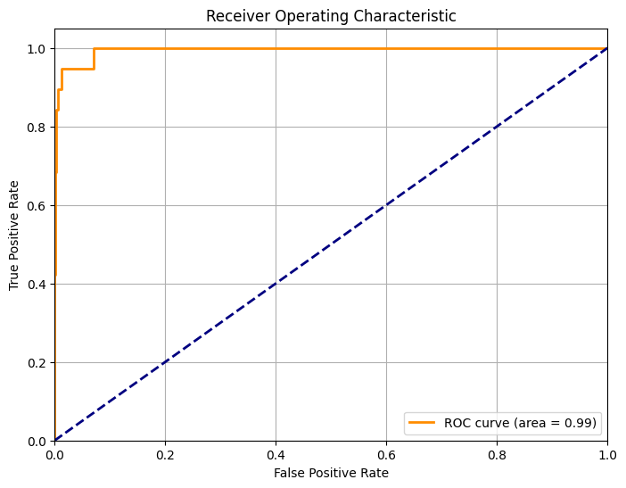

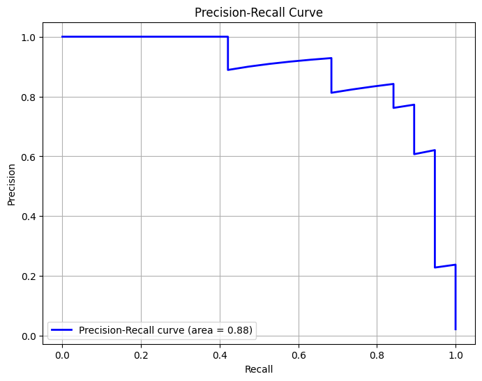

```python
# Model Evaluation
y_true_tuned = data_2023_tuned['Is_MVP']
y_scores_tuned = probs_2023_tuned

conf_matrix_tuned = confusion_matrix(y_true_tuned, predictions_2023_tuned)
print("Confusion Matrix:\n", conf_matrix_tuned)

class_report_tuned = classification_report(y_true_tuned, predictions_2023_tuned)
print("Classification Report:\n", class_report_tuned)

fpr_tuned, tpr_tuned, thresholds_tuned = roc_curve(y_true_tuned, y_scores_tuned)
roc_auc_tuned = auc(fpr_tuned, tpr_tuned)

plt.figure(figsize=(8, 6))
plt.plot(fpr_tuned, tpr_tuned, color='darkorange', lw=2, label='ROC curve (area = %0.2f)' % roc_auc_tuned)
plt.plot([0, 1], [0, 1], color='navy', lw=2, linestyle='--')
plt.grid(True)
plt.xlim([0.0, 1.0])
plt.ylim([0.0, 1.05])
plt.xlabel('False Positive Rate')
plt.ylabel('True Positive Rate')
plt.title('Receiver Operating Characteristic')
plt.legend(loc="lower right")
plt.show()

precision_tuned, recall_tuned, _ = precision_recall_curve(y_true_tuned, y_scores_tuned)
pr_auc_tuned = auc(recall_tuned, precision_tuned)

plt.figure(figsize=(8, 6))
plt.plot(recall_tuned, precision_tuned, color='blue', lw=2, label='Precision-Recall curve (area = %0.2f)' % pr_auc_tuned)
plt.grid(True)
plt.xlabel('Recall')
plt.ylabel('Precision')
plt.title('Precision-Recall Curve')
plt.legend(loc="lower left")
plt.show()

accuracy_tuned = accuracy_score(y_true_tuned, predictions_2023_tuned)

model_metrics['Tuned_Model'] = {
    'Confusion_Matrix': conf_matrix_tuned,
    'Classification_Report': class_report_tuned,
    'ROC_AUC': roc_auc_tuned,
    'Precision_Recall_AUC': pr_auc_tuned
}

# Update model_summary DataFrame
tuned_metrics = pd.DataFrame({
    'Model': ['Tuned_Model'],
    'Accuracy': [accuracy_tuned],
    'ROC AUC': [roc_auc_tuned]
})

model_summary = pd.concat([model_summary, tuned_metrics], ignore_index=True)
```

## Base Model, More Features

```python
X_new = modern_data[features_all]
y_new = modern_data['Is_MVP']


# Create preprocessing and modeling pipeline again
pipeline_new = Pipeline([
    ('imputer', SimpleImputer(strategy='median')),
    ('scaler', StandardScaler()),
    ('classifier', LogisticRegression(max_iter=1000))
])

# Splitting the data again
X_train_new, X_test_new, y_train_new, y_test_new = train_test_split(X_new, y_new, test_size=0.2, random_state=42)

# Fitting the model again
pipeline_new.fit(X_train_new, y_train_new)

# Making predictions
predictions_new = pipeline_new.predict(X_test_new)

# Evaluating the model
print(features_all)
print("Basic Model Accuracy (All Features):", accuracy_score(y_test_new, predictions_new))
print(classification_report(y_test_new, predictions_new))


# Create a copy of the 2023 data
data_2023_new = modern_data[modern_data['season'] == 2023].copy()

# Apply the same feature engineering steps as done during model training
data_2023_new['points_per_minute'] = data_2023_new['pts_per_game'] / data_2023_new['mp_per_game']
data_2023_new['efficiency_team_success'] = data_2023_new['player_per'] * data_2023_new['win_percentage']
data_2023_new['player_per_squared'] = data_2023_new['player_per'] ** 2
data_2023_new['player_vorp_cubed'] = data_2023_new['player_vorp'] ** 3
data_2023_new['player_team_points_share'] = data_2023_new['pts_per_game'] / data_2023_new.groupby('team')['pts_per_game'].transform('mean')



X_2023_new = data_2023_new[features_all]



# Predict the 2023 season MVP using the feature-engineered model
predictions_2023_new = pipeline_new.predict(X_2023_new)
probs_2023_new = pipeline_new.predict_proba(X_2023_new)[:, 1]

# Adding predictions and probabilities to the data for 2023
data_2023_new['predicted_MVP_new'] = predictions_2023_new
data_2023_new['MVP_probability_new'] = probs_2023_new

# Filtering for players with non-zero MVP probability and sort by the highest probabilities but for this model version
top_candidates_new = data_2023_new[data_2023_new['predicted_MVP_new'] == 1].sort_values('MVP_probability_new', ascending=False)

print(top_candidates_new[['player', 'MVP_probability_new']])
```

```
['player_id', 'age_playerStat', 'experience', 'g', 'gs', 'mp_per_game', 'fg_per_game', 'fga_per_game', 'fg_percent_per_game', 'player_x3p_per_game', 'x3pa_per_game', 'x3p_percent', 'x2p_per_game', 'x2pa_per_game', 'x2p_percent', 'player_e_fg_percent', 'player_ft_per_game', 'fta_per_game', 'ft_percen…
Basic Model Accuracy (All Features): 0.9905443393815487
              precision    recall  f1-score   support

           0       0.99      1.00      1.00      7712
           1       0.72      0.57      0.64       114

    accuracy                           0.99      7826
   macro avg       0.86      0.78      0.82      7826
weighted avg       0.99      0.99      0.99      7826

                     player  MVP_probability_new
1911           Nikola Jokić             0.991590
1414  Giannis Antetokounmpo             0.991424
1556            Joel Embiid             0.961598
1741           LeBron James             0.952313
1691           Kevin Durant             0.947272
1692           Kevin Durant             0.939353
1688           Kevin Durant             0.911138
1689           Kevin Durant             0.898374
1693           Kevin Durant             0.777994
1690           Kevin Durant             0.666675
1508           James Harden             0.599046
1606           Jrue Holiday             0.590072
1749            Luka Dončić             0.585704
1996      Russell Westbrook             0.530652
```

# Overall Model Evaluations

```python
# Model Evaluation
y_true_new = data_2023_new['Is_MVP']
y_scores_new = probs_2023_new

conf_matrix_new = confusion_matrix(y_true_new, predictions_2023_new)
class_report_new = classification_report(y_true_new, predictions_2023_new)
fpr_new, tpr_new, thresholds_new = roc_curve(y_true_new, y_scores_new)
roc_auc_new = auc(fpr_new, tpr_new)
precision_new, recall_new, _ = precision_recall_curve(y_true_new, y_scores_new)
pr_auc_new = auc(recall_new, precision_new)
accuracy_new = accuracy_score(y_true_new, predictions_2023_new)

model_metrics['New_Model'] = {
    'Confusion_Matrix': conf_matrix_new,
    'Classification_Report': class_report_new,
    'ROC_AUC': roc_auc_new,
    'Precision_Recall_AUC': pr_auc_new
}
```

```python
print("Model Metrics:")
for model, metrics in model_metrics.items():
    print(f"\n{model}:")
    print("Confusion Matrix:\n", metrics['Confusion_Matrix'])
    print("Classification Report:\n", metrics['Classification_Report'])
    print("ROC AUC:", metrics['ROC_AUC'])
    print("Precision-Recall AUC:", metrics['Precision_Recall_AUC'])

print("\nModel Summary:")
print(model_summary)

# Function to extract precision, recall, and F1-score from the classification report
def extract_metrics(report):
    lines = report.split('\n')
    precision_non_mvp = float(lines[2].split()[1])
    recall_non_mvp = float(lines[2].split()[2])
    f1_non_mvp = float(lines[2].split()[3])
    precision_mvp = float(lines[3].split()[1])
    recall_mvp = float(lines[3].split()[2])
    f1_mvp = float(lines[3].split()[3])
    return precision_non_mvp, recall_non_mvp, f1_non_mvp, precision_mvp, recall_mvp, f1_mvp

# Clear the model_summary DataFrame
model_summary = model_summary[:0]

# Update model_summary with metrics for each model
for model, metrics in model_metrics.items():
    accuracy = metrics['Confusion_Matrix'].diagonal().sum() / metrics['Confusion_Matrix'].sum()
    roc_auc = metrics['ROC_AUC']
    precision_non_mvp, recall_non_mvp, f1_non_mvp, precision_mvp, recall_mvp, f1_mvp = extract_metrics(metrics['Classification_Report'])

    model_summary = pd.concat([model_summary, pd.DataFrame({
        'Model': [model],
        'Accuracy': [accuracy],
        'ROC AUC': [roc_auc],
        'Precision_Non_MVP': [precision_non_mvp],
        'Recall_Non_MVP': [recall_non_mvp],
        'F1_Non_MVP': [f1_non_mvp],
        'Precision_MVP': [precision_mvp],
        'Recall_MVP': [recall_mvp],
        'F1_MVP': [f1_mvp]
    })], ignore_index=True)
```

```
Model Metrics:

Base_Model:
Confusion Matrix:
 [[865   4]
 [ 14   5]]
Classification Report:
               precision    recall  f1-score   support

           0       0.98      1.00      0.99       869
           1       0.56      0.26      0.36        19

    accuracy                           0.98       888
   macro avg       0.77      0.63      0.67       888
weighted avg       0.97      0.98      0.98       888

ROC AUC: 0.9648113378959481
Precision-Recall AUC: 0.5065986756334937

Feature_Engineered_Model:
Confusion Matrix:
 [[866   3]
 [ 14   5]]
Classification Report:
               precision    recall  f1-score   support

           0       0.98      1.00      0.99       869
           1       0.62      0.26      0.37        19

    accuracy                           0.98       888
   macro avg       0.80      0.63      0.68       888
weighted avg       0.98      0.98      0.98       888

ROC AUC: 0.9562715765247412
Precision-Recall AUC: 0.5333442736886027

Tuned_Model:
Confusion Matrix:
 [[817  52]
 [  1  18]]
```

[output cut: 27 more lines]

```
ROC AUC: 0.99351947186724
Precision-Recall AUC: 0.8952621925603874

Model Summary:
                      Model  Accuracy   ROC AUC  Precision_Non_MVP  Recall_Non_MVP  F1_Non_MVP  \
0                Base_Model  0.979730  0.964811               0.98            1.00        0.99
1  Feature_Engineered_Model  0.980856  0.956272               0.98            1.00        0.99
2               Tuned_Model  0.940315  0.994489               1.00            0.94        0.97
3                 New_Model  0.989865  0.993519               0.99            1.00        0.99

   Precision_MVP  Recall_MVP  F1_MVP
0           0.56        0.26    0.36
1           0.62        0.26    0.37
2           0.26        0.95    0.40
3           0.86        0.63    0.73
```